```python
# import library
import pickle, os
import pandas as pd
import numpy as np
import tqdm.notebook as tqdm
import copy
from scipy import stats
from scipy.stats.mstats import winsorize
from statsmodels.formula.api import ols
import matplotlib.pyplot as plt
from mpl_toolkits.mplot3d import axes3d
import seaborn as sns


os.chdir('C:\\Users\\jky93\\KYdrive\\바탕 화면\\창업\\팩터프로젝트')
# # Data Download
with open('FS_손익계산서보정본', 'rb') as f:
    data = pickle.load(f)

with open('Final_FS_ind', 'rb') as f:
    ind = pickle.load(f)

# 특정 자산만 뽑아서 csv로 정리하기
def get_item(concept_id):
    item = []
    item_ind = []
    # check id's address
    id_address = None
    for i in range(len(data)):
        for j in range(3):
            try:
                if concept_id in data[i][j].iloc[:,0].values:
                    id_address = j
            except AttributeError:
                pass
        if id_address != None:
            break

    for i in range(len(data)):
        if type(data[i][id_address]) == type(data[0][id_address]):
            item.append(data[i][id_address][data[i][id_address][data[i][id_address].columns[0]] == concept_id].iloc[:1])
            if len(data[i][id_address][data[i][id_address][data[i][id_address].columns[0]] == concept_id]) > 0:
                item_ind.append(ind[i])
    df_item = pd.concat(item)
    date = list(filter(lambda x: x[1] == ('연결재무제표',), df_item.columns))
    if id_address ==0:
        date_clean = list(map(lambda x: x[0], df_item[date].columns))
        df_item[date].columns = date_clean
        df_item2 = df_item[date]
        df_item2.columns = date_clean
        date_shifted = list(map(lambda x: shift_q(x), date_clean))
        df_item3 = df_item2
        df_item3.columns = date_shifted
        df_item4 = df_item3.groupby(level=0, axis=1).last()
        df_item3 = df_item4
        date_shifted2 = list(map(lambda x: shift_d(x), df_item4.columns))
        df_item3.columns = date_shifted2
        df_item5 = df_item3.groupby(level=0, axis=1).last()
        corp_code = list(map(lambda x:x[2], item_ind))
        df_item5['corp_code'] = corp_code
        df_item5 = df_item5.set_index('corp_code')
    else:
        date_clean = list(map(lambda x: x[0], df_item[date].columns))
        df_item[date].columns = date_clean
        df_item2 = df_item[date]
        df_item2.columns = date_clean
        date_shifted = list(map(lambda x: shift_flow_date(x), date_clean))
        df_item2.columns = date_shifted
        df_item3 = df_item2.groupby(level=0, axis=1).last()
        corp_code = list(map(lambda x:x[2], item_ind))
        df_item3['corp_code'] = corp_code
        df_item3 = df_item3.set_index('corp_code')
        df_item5 = df_item3
    return df_item5

def shift_q(date):
    if date[4:6]=='01' or date[4:6]=='02' or date[4:6]=='03':
        date = date[:4] + '0331'
    elif date[4:6]=='04' or date[4:6]=='05' or date[4:6]=='06':
        date = date[:4] + '0630'
    elif date[4:6]=='07' or date[4:6]=='08' or date[4:6]=='09':
        date = date[:4] + '0930'
    elif date[4:6]=='10' or date[4:6]=='11' or date[4:6]=='12':
        date = date[:4] + '1231'
    return date

def shift_d(date):
    # 케이스 두개 밖에 안되니까 그냥 수동으로 따져주자.
    if date[6:]=='01':
        date = date[:6] + '31'
    elif date[6:]=='29':
        date = date[:6] + '30'
    return date

def shift_flow_date(date):
    # 우선은 연간 데이터만 활용하도록 만들어놓아도 될 듯? 나중에 분기별로 뽑을 수 있는 옵션을 추가해야 할 것 같다.
    if date[4:6]=='01' and date[-4:-2]=='12':
        date = date[-8:-2] + '31'
    else:
        date = None
    return date

def get_item_on_date(item, date):
    return get_item(item)[date]

def get_item_for_period(item, date_from, date_to, term = 'Y'):
    # term은 Y, H, Q의 세 가지 옵션으로, 연도별, 반기별, 분기별 데이터를 얻어올 수 있도록 하는 옵션이다.
    data = []
    item_data = get_item(item)
    if term == 'Y':
        num = int(date_to[:4]) - int(date_from[:4]) +1
        date_working = date_from
        for i in range(num):
            data.append(item_data[date_working])
            date_working = date_working[:2] + str(int(date_working[2:4]) + 1) + date_working[4:]

    elif term == 'H':
        num = int((int(date_to[:4]) - int(date_from[:4])) * 2 + (int(date_to[4:6]) - int(date_from[4:6]))/6 + 1)
        date_working = date_from
        for i in range(num):
            try:
                data.append(item_data[date_working])
            except:
                try:
                    date_working = date_working[:6] + str(61 - int(date_working[6:]))
                    data.append(item_data[date_working])
                except KeyError:
                    print('해당 날짜의 데이터가 없습니다:', date_working)
            if int(date_working[4:6])+6 > 12:
                date_working = date_working[:2] + str(int(date_working[2:4]) + 1) +'0'+ str(int(date_working[4:6])-6)+'31'
            else:
                date_working = date_working[:4] + str(int(date_working[4:6]) + 6).zfill(2) + '31'

    else:
        num = int((int(date_to[:4]) - int(date_from[:4])) * 4 + (int(date_to[4:6]) - int(date_from[4:6]))/3 + 1)
        date_working = date_from
        for i in range(num):
            try:
                data.append(item_data[date_working])
            except:
                try:
                    date_working = date_working[:6] + str(61 - int(date_working[6:]))
                    data.append(item_data[date_working])
                except KeyError:
                    print('해당 날짜의 데이터가 없습니다:', date_working)
            if int(date_working[4:6])+3 > 12:
                date_working = date_working[:2] + str(int(date_working[2:4]) + 1) +'0331'
            else:
                date_working = date_working[:4] + str(int(date_working[4:6]) + 3).zfill(2) + '31'

    data = pd.concat(data, axis = 1)
    return data


def get_market_data_on_date(date, print_error = True):
    # 에러 메시지를 출력하고 싶지 않으면 print_error를 False로 설정
    os.chdir('C:\\Users\\jky93\\KYdrive\\바탕 화면\\창업\\팩터프로젝트\\KRX_price')
    try:
        data = pd.read_csv(date[2:4] + '_' + str(int(date[4:6])) + '_' + str(int(date[6:8])) + '.csv', encoding = 'cp949')
        data['종목코드'] = data['종목코드'].map(lambda x:str(x).zfill(6) if x != None else None)
        if data.isna()['종가'].sum() == len(data):
            raise FileNotFoundError
    except FileNotFoundError:
        if print_error:
            print('해당 날짜의 데이터가 존재하지 않습니다:', date)
        data = None
    return data
```

```python
def get_market_cap_on_date(date, get_code = False):
    if get_code:
        data = get_market_data_on_date(date)[['종목코드','시장구분','시가총액']].set_index('종목코드')
        data.columns = [['시장구분','Market_Cap']]
    else:
        data = get_market_data_on_date(date)[['종목코드','시가총액']].set_index('종목코드')
        data.columns = [['Market_Cap']]
    data.index.rename('corp_code', inplace = True)
    return data

def last_market_date(date):
    # date의 기본형식은 'YYYYMM' : ex)'201212'. -> 'YYYYMMDD'도 가능하도록 코드 변경했음
    get_data = False
    day = 31
    while not get_data:
        if type(get_market_data_on_date(date[:6] + str(day), print_error = False)) != type(None):
            market_date = date[:6] + str(day)
            get_data = True
        else:
            day -=1
    return market_date

def find_next_market_date(date, today_opt = False):
    get_data = False
    if today_opt:
        market_date = pd.Timestamp(date)
    else:
        market_date = pd.Timestamp(date) + pd.Timedelta(days=1)
    while not get_data:
        if type(get_market_data_on_date(market_date.strftime('%Y%m%d'), print_error = False)) != type(None):
            get_data = True
        else:
            market_date += pd.Timedelta(days=1)

    return market_date.strftime('%Y%m%d')

def get_market_cap_for_period(date_from, date_to, term = 'Y', ind_match = True):
    # ind_match는 fundamental과 합치기 편하도록 실제 날짜가 아니라 월말 날짜를 표시하도록 하는 옵션
    data = []
    ind = []
    if term == 'Y':
        num = int(date_to[:4]) - int(date_from[:4]) +1
        date_working = date_from
        for i in range(num):
            data.append(get_market_cap_on_date(last_market_date(date_working), get_code = True))
            if ind_match:
                ind.append(date_working)
            else:
                ind.append(last_market_date(date_working))
            date_working = date_working[:2] + str(int(date_working[2:4]) + 1) + date_working[4:]

    elif term == 'H':
        num = int((int(date_to[:4]) - int(date_from[:4])) * 2 + (int(date_to[4:6]) - int(date_from[4:6]))/6 + 1)
        date_working = date_from
        for i in range(num):
            data.append(get_market_cap_on_date(last_market_date(date_working), get_code = True))
            if ind_match:
                ind.append(date_working)
            else:
                ind.append(last_market_date(date_working))
            if int(date_working[4:6])+6 > 12:
                date_working = date_working[:2] + str(int(date_working[2:4]) + 1) +'0'+ str(int(date_working[4:6])-6)+'31'
            else:
                date_working = date_working[:4] + str(int(date_working[4:6]) + 6).zfill(2) + '31'

    else:
        num = int((int(date_to[:4]) - int(date_from[:4])) * 4 + (int(date_to[4:6]) - int(date_from[4:6]))/3 + 1)
        date_working = date_from
        for i in range(num):
            data.append(get_market_cap_on_date(last_market_date(date_working), get_code = True))
            if ind_match:
                ind.append(date_working)
            else:
                ind.append(last_market_date(date_working))
            if int(date_working[4:6])+3 > 12:
                date_working = date_working[:2] + str(int(date_working[2:4]) + 1) +'0331'
            else:
                date_working = date_working[:4] + str(int(date_working[4:6]) + 3).zfill(2) + '31'
    cap_data = [x.iloc[:,1] for x in data]
    cat_data = [x.iloc[:,0] for x in data]
    cap_data = pd.concat(cap_data, axis =1)
    cap_data.columns = ind
    cat_data = pd.concat(cat_data, axis =1)
    cat_data.columns = ind
    return cap_data, cat_data

def get_market_category(data):
    market_cat = []
    for i in range(len(data.columns)):
        market_cat.append(get_market_cap_on_date(last_market_date(data.columns[i]), get_code = True).iloc[:,0])
    market_cat = pd.concat(market_cat, axis=1)
    market_cat.columns = data.columns
    return market_cat

def get_breakpoint(data, breakpoint):
    absolute_point = []
    rank = data.rank(pct=True)
    for i in range(len(breakpoint)):
        absolute_point.append((data[rank < breakpoint[i]].max() + data[rank > breakpoint[i]].min())/2)
    return absolute_point

def get_mask(data, market_cat = None, market_bp = 'All', breakpoint: list = [0.5]):
    # data는 mask의 기준이 되는 baseline data
    # market_bp는 'ALL', 'KOSPI', 'KOSDAQ'으로, 기준이 되는 breakpoint의 market을 의미
    # breakpoint는 masking의 구분점으로, list안에 float이 담긴 형태를 받음
    breakpoint = np.sort(breakpoint)
    mask_list = []

    data_ind = data.index
    if type(market_cat) != type(None):
        market_cat = market_cat[market_cat.index.map(lambda x: x in data.index)]
        for i in range(len(data)):
            if data_ind[i] not in market_cat.index:
                market_cat.loc[data_ind[i]] = None
        market_cat = market_cat.reindex(index = data.index)
    for i in range(len(data.columns)):
        mask = data.iloc[:,i] * 0 +1
        mask_np = -np.ones(len(mask))
        #rank = data.iloc[:,i].rank(pct = True)
        if market_bp == 'All':
            absolute_point = get_breakpoint(data.iloc[:,i], breakpoint)
        if market_bp == 'KOSPI':
            absolute_point = get_breakpoint(data[market_cat.iloc[:,i]=='KOSPI'].iloc[:,i], breakpoint)
        if market_bp == 'KOSDAQ':
            absolute_point = get_breakpoint(data[market_cat.iloc[:,i]=='KOSDAQ'].iloc[:,i], breakpoint)
        for j in range(len(breakpoint)+1):
            if j < len(breakpoint):
                for k in range(len(mask)):
                    mask_np[k] = j if data.iloc[k,i] < absolute_point[j] and mask_np[k] == -1 else mask_np[k]
            else:
                for k in range(len(mask)):
                    mask_np[k] = j if data.iloc[k,i] > absolute_point[j-1] and mask_np[k] == -1 else mask_np[k]
        mask = mask * mask_np
        mask_list.append(mask)
    mask_df = pd.concat(mask_list, axis =1)
    return mask_df

def shift_date_quarter(data, num_of_quarters):
    # data의 date를 원하는 만큼 밀어줌.
    dates = data.columns
    years = [int(x[:4]) for x in dates]
    months = [int(x[4:6]) for x in dates]
    shifted_months = [x + num_of_quarters * 3 for x in months]
    shifted_years = [x + (shifted_months[i]-1) // 12 for i, x in enumerate(years)]
    shifted_months = [(x -1) % 12 +1 for x in shifted_months]
    dates = [str(shifted_years[i]) + str(shifted_months[i]).zfill(2)+ '30' if shifted_months[i] in [6, 9] else str(shifted_years[i]) + str(shifted_months[i]).zfill(2)+ '31' for i in np.arange(len(years))]
    data2 = copy.deepcopy(data)
    data2.columns = dates
    return data2
```

```python
def get_factor_on_date_by_mask(mask, term = 'd', winsorize_limits = 0.01, weight = 'EW'):
    # @@@@@@@@@@@ option 추가해야할듯! : daily / weekly / monthly / quarterly 정도까지는 구현을 해놓아야할듯
    # monthly 계산할 때 첫 달은 어떻게 계산하는거지? 전달 말일 기준으로 계산하나? 아니면 해당 달 시초가 기준으로 계산하나?
    # -> 우선 첫 달은 시가 기준, 이후로는 전달 말일에 리밸런싱 하는 걸 기준으로 계산했음.
    term_conservative = pd.Timestamp(mask.columns[1]) - pd.Timestamp(mask.columns[0]) - pd.Timedelta(days = 7)
    if pd.Timestamp(mask.columns[-1]) + term_conservative >  pd.Timestamp('20210630'):
        date_to = pd.Timestamp('20210630')
    else:
        date_to = pd.Timestamp(last_market_date((pd.Timestamp(mask.columns[-1]) + term_conservative).strftime('%Y%m%d')))
    date_from = pd.Timestamp(mask.columns[0])
    factor_days = (date_to - date_from).days
    factor_months = (date_to.year - date_from.year)*12 + (date_to.month - date_from.month)

    date_point = date_from.strftime('%Y%m%d')
    # this is for storing the last date
    date_point_marked = None

    total_factor = []
    date_list = []

    if term == 'd':
        flag = -1
#         for _ in range(factor_days):
        for _ in tqdm.tqdm(range(10)):
            if pd.Timestamp(find_next_market_date(date_point)) > pd.Timestamp(mask.columns[flag+1]):
                flag+=1
                c_mask = mask.iloc[:,flag]
            date_point_marked = date_point
            first = get_market_data_on_date(date_point_marked, print_error = False).loc[:,['종목코드', '종가', '시가총액', '등락률']]
            date_point = find_next_market_date(date_point_marked)
            second = get_market_data_on_date(date_point, print_error = False).loc[:,['종목코드', '종가', '시가총액', '등락률']]
            date_list.append(date_point)
            return_list = [[] for x in np.arange(mask.max()[0]+1)]
            value_list = [[] for x in np.arange(mask.max()[0]+1)]
            for i in range(len(first)):
                if first.iloc[i,0] in c_mask.index and c_mask.notna().loc[first.iloc[i,0]]:
                    if second.notna()[second['종목코드'] == first.iloc[i,0]].iloc[0,0]:
                        return_list[int(c_mask.loc[first.iloc[i,0]])].append(second[second['종목코드'] == first.iloc[i,0]].iloc[0,3])
                    else:
                        return_list[int(c_mask.loc[first.iloc[i,0]])].append(-0.99)
                    value_list[int(c_mask.loc[first.iloc[i,0]])].append(first.iloc[i,2])

            if weight == 'VW':
                for i in range(len(return_list)):
                    # len을 곱해준 건 나중에 mean에서 EW와 같은 형태로 들어가게 하도록 하기 위함.
                    return_list[i] *= value_list[i]/ np.sum(value_list[i]) * len(value_list[i])

            # winsorize
            if winsorize_limits > 0:
                for i in range(len(return_list)):
                    return_list[i] = winsorize(return_list[i], limits = winsorize_limits)

            factor = [np.mean(x) for x in return_list]
            total_factor.append(factor)
        return pd.DataFrame(total_factor, index = date_list)
    elif term == 'm':
        flag = -1
        for _ in tqdm.tqdm(range(factor_months)):
            if flag +1 == mask.shape[1]:
                c_mask = mask.iloc[:,flag]
                date_point_marked = date_point
                first = (get_market_data_on_date(date_point_marked, print_error = False).loc[:,['종목코드', '시가', '시가총액', '등락률']]).set_index('종목코드')
                c_mask = c_mask.loc[list(filter(lambda x: x in first.index, c_mask[c_mask.notna()].index))]
            elif pd.Timestamp(find_next_market_date(date_point)) > pd.Timestamp(mask.columns[flag+1]):
                flag+=1
                c_mask = mask.iloc[:,flag]
                date_point_marked = last_market_date(date_point)
                first = (get_market_data_on_date(date_point_marked, print_error = False).loc[:,['종목코드', '시가', '시가총액', '등락률']]).set_index('종목코드')
                c_mask = c_mask.loc[list(filter(lambda x: x in first.index, c_mask[c_mask.notna()].index))]
            else:
                date_point_marked = date_point
                first = (get_market_data_on_date(date_point_marked, print_error = False).loc[:,['종목코드', '종가', '시가총액', '등락률']]).set_index('종목코드')

            # 통일된 수식으로 flag가 바뀐 경우의 말일을 계산할 수 있음
            date_point = last_market_date(find_next_market_date(date_point_marked))
            second = (get_market_data_on_date(date_point, print_error = False).loc[:,['종목코드', '종가', '시가총액', '등락률']]).set_index('종목코드')
            date_list.append(date_point[:6])
            return_value = get_market_return_for_period(date_point_marked, date_point)
            return_list = []
            value_list = []
            for i in range(int(mask.max()[0]+1)):
                return_list.append(return_value.loc[c_mask[c_mask == i].index].loc[:,['등락률']].values)
                value_list.append(return_value.loc[c_mask[c_mask == i].index].loc[:,['시가총액']].values)
            c_mask.drop(list(set(c_mask.index) - set(second.index)), inplace=True)
            if weight == 'VW':
                for i in range(len(return_list)):
                    # len을 곱해준 건 나중에 mean에서 EW와 같은 형태로 들어가게 하도록 하기 위함.
                    return_list[i] *= value_list[i]/ np.sum(value_list[i]) * len(value_list[i])
            # winsorize
            if winsorize_limits > 0:
                for i in range(len(return_list)):
                    return_list[i] = winsorize(return_list[i], limits = winsorize_limits)
            factor = [np.mean(x) for x in return_list]
            total_factor.append(factor)
        return pd.DataFrame(total_factor, index = date_list)
```

# Pfo Construction

```python
def make_portfolio(pfo, factor, market_bp= 'All', breakpoint=[0.5]):
    # 여기서 앞에 들어가는 거는 마스크, 뒤에 들어가는 거는 실제값.
    max_num = int(pfo.max()[0]+1)
    new_df = pd.DataFrame(index = pfo.index, columns = pfo.columns)
    for i in range(len(pfo.columns)):
        for j in range(max_num):
            get_index = list(filter(lambda x: x in factor.index, pfo.iloc[:,i][pfo.iloc[:,i]==j].index))
            pfo_mask = get_mask(pd.DataFrame(factor.loc[get_index].iloc[:,i]), get_market_category(pd.DataFrame(factor.loc[get_index].iloc[:,i])), market_bp, breakpoint)
            new_df.iloc[:,i].loc[pfo_mask.index] = pfo_mask.values[:,0]
    return new_df

def serialize_pfo(mask_list: list):
    # 사전식 배열. 앞에서부터 사전식으로 serialize하여 뱉음
    serial_num = [x.max().max()+1 for x in mask_list]
    for i in reversed(range(len(serial_num)-1)):
        serial_num[i] *= serial_num[i+1]
    serial_num += [1]
    serial_num = serial_num[1:]
    serial_elem = [x * mask_list[i] for i, x in enumerate(serial_num)]
    for i in range(len(serial_elem)-1):
        serial_elem[0] += serial_elem[i+1]
    return serial_elem[0]
```

# Regression 해볼 수 있도록 만들기

```python
def get_market_return_for_period(date_from, date_to):
    first = get_market_data_on_date(find_next_market_date(date_from, today_opt = True), print_error = False).loc[:, ['종목코드', '종가', '시가총액']].set_index('종목코드')
    df = pd.DataFrame()
    flag = find_next_market_date(date_from, today_opt = True)
    while flag != date_to:
        flag = find_next_market_date(flag)
        df = pd.concat([df, get_market_data_on_date(flag, print_error = False).loc[:,['종목코드', '등락률']].set_index('종목코드').rename({'등락률':flag}, axis=1)], axis=1)
        if flag == date_to:
            second = get_market_data_on_date(flag, print_error = False).loc[:, ['종목코드', '종가']].set_index('종목코드')
    df = df.applymap(lambda x: (100 + x)/100)
    for i in range(len(df.columns)):
        if i == 0:
            geo_sum = df.iloc[:,i].copy()
        else:
            geo_sum *= df.values[:,i]
    compute_by_price = second['종가'] / first['종가']
    # 가정 : 3% 이상 차이가 날 수 없다. 계산상 최대 1프로 정도 차이지만, 좀 갭을 두었음.
    final_return = (compute_by_price - geo_sum < 0.03) * compute_by_price + (compute_by_price - geo_sum >= 0.03) * geo_sum
    final_return = pd.concat([final_return.loc[first.index].fillna(0.01), first['시가총액']], axis=1).rename({0:'등락률'}, axis=1)
    final_return['등락률'] = final_return['등락률'] -1
    return final_return
```

```python
def get_market_return(mask, term = 'd'):
    term_conservative = pd.Timestamp(mask.columns[1]) - pd.Timestamp(mask.columns[0]) - pd.Timedelta(days = 7)
    if pd.Timestamp(mask.columns[-1]) + term_conservative >  pd.Timestamp('20210630'):
        date_to = pd.Timestamp('20210630')
    else:
        date_to = pd.Timestamp(last_market_date((pd.Timestamp(mask.columns[-1]) + term_conservative).strftime('%Y%m%d')))
    date_from = pd.Timestamp(mask.columns[0])
    factor_days = (date_to - date_from).days
    factor_months = (date_to.year - date_from.year)*12 + (date_to.month - date_from.month)

    date_point = date_from.strftime('%Y%m%d')
    # this is for storing the last date
    date_point_marked = None

    total_return = []
    date_list = []

    if term == 'd':
        flag = -1
        date_point = find_next_market_date(date_point)
        for _ in tqdm.tqdm(range(factor_days)):
            if pd.Timestamp(find_next_market_date(date_point)) > pd.Timestamp(mask.columns[flag+1]):
                flag+=1
                c_mask = mask.iloc[:,flag]
            first = get_market_data_on_date(date_point, print_error = False).loc[:,['종목코드', '종가', '시가총액', '등락률']]
            date_list.append(date_point)
            date_point = find_next_market_date(date_point)

            market_cap = first['시가총액'].sum()
            R = first['등락률'] * (first['시가총액'] / market_cap)
            total_return.append(R.fillna(0).sum())

        return pd.DataFrame(total_return, index = date_list)
    elif term == 'm':
        flag = -1
        for _ in tqdm.tqdm(range(factor_months)):
            if flag +1 == mask.shape[1]:
                c_mask = mask.iloc[:,flag]
                date_point = find_next_market_date(date_point)
                date_point_marked = date_point
            elif pd.Timestamp(find_next_market_date(date_point)) > pd.Timestamp(mask.columns[flag+1]):
                flag+=1
                c_mask = mask.iloc[:,flag]
                date_point_marked = last_market_date(date_point)
            else:
                date_point_marked = date_point

            date_point = last_market_date(find_next_market_date(date_point_marked))
            return_value = get_market_return_for_period(date_point_marked, date_point)
            date_list.append(date_point[:6])
            market_cap = return_value['시가총액'].sum()
            R = return_value['등락률'] * (return_value['시가총액'] / market_cap)

            total_return.append(R.replace([np.inf, -np.inf], np.nan).fillna(0).sum())
        return pd.DataFrame(total_return, index = date_list)
```

# 모듈화하기

```python
def get_risk_free_rate(pfo, risk_free):
    return risk_free.loc[pfo.index]

def get_ols_model(mask, R_m, pfo_column, risk_free, *args):
    R_f = (get_risk_free_rate(pfo_column, risk_free).astype(float)/1200).squeeze() #monthly로 바꾸고 %를 소수로 바꿔야하므로 1200으로 나눔
    df = pd.DataFrame([(pfo_column - R_f.T).values.squeeze(), (R_m - R_f).values.squeeze()] + [x.values.squeeze() for x in args]).T
    df.columns = ['pfo', 'market'] + ['factor' + str(i) for i, x in enumerate(args)]
    var_str = ''
    for i in range(len(df.columns)-2):
        var_str += ' + ' + ['factor' + str(i) for i, x in enumerate(args)][i]
    model = ols(formula = 'pfo ~ market' + var_str,data = df).fit()
    return model
```

# 이제 FF5 구현해보자.

## FF5 model with 크롤링 데이터

- 2009년(CMA), 2010년(HML, RMW), 2011년(SMB) 데이터부터 써서 2011년 6월30일 종가 기준 리밸런싱이 처음.
- 2018년(CMA), 2019년(HML, RMW), 2020년(SMB) 데이터까지 써서 2020년 6월30일 종가 기준 리밸런싱이 마지막.
- 따라서 regression의 기간은 2011년 7월 ~ 2021년 6월
- 상하위 1% winsorization
- (size/BEME), (size/OP), (size/INV)로 25포트폴리오에 대해 OLS분석 #### 차례
1. (size/BEME) 25포트폴리오에 대해 OLS분석  
   (1) Rm, SMB, HML, RMW, CMA로 regression  
   (2) HML를 다른 4개 팩터에 projection시켜서 HMLO로 대체
2. (size/OP) 25포트폴리오에 대해 OLS분석  
   (1) Rm, SMB, HML, RMW, CMA로 regression  
   (2) HML를 다른 4개 팩터에 projection시켜서 HMLO로 대체
3. (size/INV)로 25포트폴리오에 대해 OLS분석  
   (1) Rm, SMB, HML, RMW, CMA로 regression  
   (2) HML를 다른 4개 팩터에 projection시켜서 HMLO로 대체
4. 블룸버그 데이터와의 비교 (우리 데이터가 괜찮음을 증명)
5. Size/BEME 25 portfolio에 대해 Window Regression

```python
# risk free rate
os.chdir('C:\\Users\\jky93\\KYdrive\\바탕 화면\\창업\\팩터프로젝트')
cd_91 = pd.read_csv('cd금리.csv', encoding='cp949', header=2, index_col=0).T.iloc[:, [4]]
cd_91.index = cd_91.index.map(lambda x: x[:6])
cd_91.columns = ['cd_91']
os.chdir('C:\\Users\\jky93\\KYdrive\\바탕 화면\\창업\\팩터프로젝트\\KRX_price')
```

```python
Market_cap = get_market_cap_for_period('20101231', '20191231')

equity = get_item_for_period('ifrs_Equity', '20101231', '20191231')

BEME = equity/Market_cap[0]
```

```python
Market_cap = get_market_cap_for_period('20110630', '20200630')
```

```python
# SMB
SMB_mask = get_mask(Market_cap[0], get_market_category(Market_cap[0]), market_bp = 'KOSPI')

SMB = get_factor_on_date_by_mask(SMB_mask, term = 'm', winsorize_limits = 0.01, weight = 'VW')
```

```python
# HML
BEME_shifted = shift_date_quarter(BEME, 2)

HML_mask = get_mask(BEME_shifted, get_market_category(BEME_shifted), market_bp = 'KOSPI', breakpoint = [0.3, 0.7])

HML = get_factor_on_date_by_mask(HML_mask, term = 'm', winsorize_limits = 0.01, weight = 'VW')
```

```python
# RMW 계산하기
# (영업이익 - 이자비용) / 총자산
Total_asset = get_item_for_period('ifrs_Assets', '20101231', '20191231')
fcost1 = get_item_for_period('ifrs_FinanceCosts', '20101231', '20191231')
fcost2 = get_item_for_period('dart_InterestExpenseFinanceExpense', '20101231', '20191231')
fcost = pd.concat([fcost1, fcost2], axis = 1).groupby(level=0, axis=1).last()
OI = get_item_for_period('dart_OperatingIncomeLoss', '20101231', '20191231')
```

```python
RMW_base = (OI - fcost) / Total_asset

RMW_base_shifted = shift_date_quarter(RMW_base, 2)

RMW_mask = get_mask(RMW_base_shifted, get_market_category(RMW_base_shifted), market_bp = 'KOSPI', breakpoint = [0.3, 0.7])

RMW = get_factor_on_date_by_mask(RMW_mask, term = 'm', winsorize_limits = 0.01, weight = 'VW')
```

```python
# CMA 계산하기

Total_asset = get_item_for_period('ifrs_Assets', '20091231', '20181231')
pnl = get_item_for_period('ifrs_ProfitLoss', '20101231', '20191231')
Total_asset_shifted = shift_date_quarter(Total_asset, 4)
CMA_base = pnl / Total_asset_shifted
CMA_base_shifted = shift_date_quarter(CMA_base, 2)
CMA_mask = get_mask(CMA_base_shifted, get_market_category(CMA_base_shifted), market_bp = 'KOSPI', breakpoint = [0.3, 0.7])
CMA = get_factor_on_date_by_mask(CMA_mask, term = 'm', winsorize_limits = 0.01, weight = 'VW')
```

```python
Rf = (get_risk_free_rate(SMB, cd_91).astype(float)/1200).squeeze()
```

```python
#팩터 정리
factors = pd.concat([(get_market_return(SMB_mask, term='m').squeeze()), Rf, SMB.iloc[:,0] - SMB.iloc[:,1], HML.iloc[:,2]- HML.iloc[:,0], RMW.iloc[:,2] - RMW.iloc[:,0], CMA.iloc[:,0] - CMA.iloc[:,2]], axis=1, join='inner')
factors.columns = ['Rm', 'risk-free', 'SMB', 'HML', 'RMW', 'CMA']
factors
```

|  | Rm | risk-free | SMB | HML | RMW | CMA |
| --- | --- | --- | --- | --- | --- | --- |
| 201107 | 0.022227 | 0.002992 | 0.067616 | 0.027316 | -0.036970 | 0.042315 |
| 201108 | -0.114518 | 0.002992 | 0.014303 | 0.054783 | 0.020513 | -0.001481 |
| 201109 | -0.060949 | 0.002983 | -0.041692 | -0.039419 | 0.018520 | -0.063712 |
| 201110 | 0.079782 | 0.002983 | 0.034043 | -0.038057 | -0.044172 | 0.038830 |
| 201111 | -0.029902 | 0.002967 | 0.032046 | 0.017156 | 0.021897 | -0.001703 |
| ... | ... | ... | ... | ... | ... | ... |
| 202102 | -0.019686 | 0.000608 | 0.008442 | 0.027952 | -0.020603 | 0.004320 |
| 202103 | 0.008959 | 0.000625 | 0.049235 | 0.043832 | 0.001327 | 0.030240 |
| 202104 | -0.000869 | 0.000617 | 0.049014 | 0.031919 | -0.036813 | 0.043665 |
| 202105 | 0.020393 | 0.000567 | 0.004343 | 0.034795 | 0.022790 | 0.015164 |
| 202106 | 0.026090 | 0.000550 | 0.032685 | -0.000403 | -0.000863 | 0.014150 |

120 rows × 6 columns

```python
HMLO_ols = ols(formula = 'HML ~ Rm+SMB+RMW+CMA', data = factors).fit()
HMLO_ols.summary()
```

OLS Regression Results

| Dep. Variable: | HML | R-squared: | 0.218 |
| --- | --- | --- | --- |
| Model: | OLS | Adj. R-squared: | 0.191 |
| Method: | Least Squares | F-statistic: | 8.003 |
| Date: | Sat, 02 Apr 2022 | Prob (F-statistic): | 9.96e-06 |
| Time: | 12:06:28 | Log-Likelihood: | 260.94 |
| No. Observations: | 120 | AIC: | -511.9 |
| Df Residuals: | 115 | BIC: | -497.9 |
| Df Model: | 4 |  |  |
| Covariance Type: | nonrobust |  |  |

|  | coef | std err | t | P>\|t\| | [0.025 | 0.975] |
| --- | --- | --- | --- | --- | --- | --- |
| Intercept | 0.0047 | 0.003 | 1.776 | 0.078 | -0.001 | 0.010 |
| Rm | 0.0287 | 0.067 | 0.427 | 0.671 | -0.105 | 0.162 |
| SMB | 0.0723 | 0.097 | 0.742 | 0.459 | -0.121 | 0.265 |
| RMW | -0.1546 | 0.165 | -0.939 | 0.350 | -0.481 | 0.172 |
| CMA | 0.3090 | 0.198 | 1.560 | 0.121 | -0.083 | 0.701 |

| Omnibus: | 9.530 | Durbin-Watson: | 2.022 |
| --- | --- | --- | --- |
| Prob(Omnibus): | 0.009 | Jarque-Bera (JB): | 15.969 |
| Skew: | -0.316 | Prob(JB): | 0.000341 |
| Kurtosis: | 4.672 | Cond. No. | 96.6 |

Notes:  
[1] Standard Errors assume that the covariance matrix of the errors is correctly specified.

```python
beta_Rm = HMLO_ols.params['Rm']
beta_SMB = HMLO_ols.params['SMB']
beta_RMW = HMLO_ols.params['RMW']
beta_CMA = HMLO_ols.params['CMA']
HMLO = pd.DataFrame(factors["HML"] - beta_Rm * factors['Rm'].squeeze() - beta_SMB*factors['SMB'].squeeze() - beta_RMW*factors['RMW'].squeeze() - beta_CMA*factors['CMA'].squeeze())
HMLO.columns = ['HMLO']
factors = pd.concat([factors, HMLO], axis=1)
factors
```

|  | Rm | risk-free | SMB | HML | RMW | CMA | HMLO |
| --- | --- | --- | --- | --- | --- | --- | --- |
| 201107 | 0.022227 | 0.002992 | 0.067616 | 0.027316 | -0.036970 | 0.042315 | 0.002997 |
| 201108 | -0.114518 | 0.002992 | 0.014303 | 0.054783 | 0.020513 | -0.001481 | 0.060668 |
| 201109 | -0.060949 | 0.002983 | -0.041692 | -0.039419 | 0.018520 | -0.063712 | -0.012103 |
| 201110 | 0.079782 | 0.002983 | 0.034043 | -0.038057 | -0.044172 | 0.038830 | -0.061638 |
| 201111 | -0.029902 | 0.002967 | 0.032046 | 0.017156 | 0.021897 | -0.001703 | 0.019611 |
| ... | ... | ... | ... | ... | ... | ... | ... |
| 202102 | -0.019686 | 0.000608 | 0.008442 | 0.027952 | -0.020603 | 0.004320 | 0.023386 |
| 202103 | 0.008959 | 0.000625 | 0.049235 | 0.043832 | 0.001327 | 0.030240 | 0.030876 |
| 202104 | -0.000869 | 0.000617 | 0.049014 | 0.031919 | -0.036813 | 0.043665 | 0.009215 |
| 202105 | 0.020393 | 0.000567 | 0.004343 | 0.034795 | 0.022790 | 0.015164 | 0.032734 |
| 202106 | 0.026090 | 0.000550 | 0.032685 | -0.000403 | -0.000863 | 0.014150 | -0.008021 |

120 rows × 7 columns

### Confirm monotonitcity and t-test

```python
SMB_mon_mask = get_mask(Market_cap[0], get_market_category(Market_cap[0]), market_bp = 'KOSPI', breakpoint=[0.1, 0.2, 0.3, 0.4, 0.5, 0.6, 0.7, 0.8, 0.9])

SMB_mon = get_factor_on_date_by_mask(SMB_mon_mask, term = 'm', winsorize_limits = 0.01, weight = 'VW')
```

```python
HML_mon_mask = get_mask(BEME_shifted, get_market_category(BEME_shifted), market_bp = 'KOSPI', breakpoint=[0.1, 0.2, 0.3, 0.4, 0.5, 0.6, 0.7, 0.8, 0.9])

HML_mon = get_factor_on_date_by_mask(HML_mon_mask, term = 'm', winsorize_limits = 0.01, weight = 'VW')
```

```python
RMW_mon_mask = get_mask(RMW_base_shifted, get_market_category(RMW_base_shifted), market_bp = 'KOSPI', breakpoint=[0.1, 0.2, 0.3, 0.4, 0.5, 0.6, 0.7, 0.8, 0.9])

RMW_mon = get_factor_on_date_by_mask(RMW_mon_mask, term = 'm', winsorize_limits = 0.01, weight = 'VW')
```

```python
CMA_mon_mask = get_mask(CMA_base_shifted, get_market_category(RMW_base_shifted), market_bp = 'KOSPI', breakpoint=[0.1, 0.2, 0.3, 0.4, 0.5, 0.6, 0.7, 0.8, 0.9])

CMA_mon = get_factor_on_date_by_mask(CMA_mon_mask, term = 'm', winsorize_limits = 0.01, weight = 'VW')
```

```python
def article(excess_name, mon, Rf, cols=['P1 (low)', 'P2', 'P3', 'P4', 'P5', 'P6', 'P7', 'P8', 'P9', 'P10 (high)']):
    from scipy import stats
    excess = mon.apply(lambda x: x- Rf, axis=0)
    std = np.std(mon)
    t_stat, p_val = stats.ttest_1samp(excess, 0)
    plt.title('Excess return of {} sorted portfolios'.format(excess_name))
    graph = plt.bar(x=cols, height=excess.mean())
    excess_mean = excess.mean().values
    sharpe = excess_mean / std
    table = pd.DataFrame([excess_mean, t_stat, p_val, sharpe])
    table.columns = cols
    table.index=['excess return', 't-stat', 'p-value', 'sharpe']
    return graph, table
```

```python
def reshape(row, width, w_num, length, l_num):
    df = pd.concat([row.iloc[(i)*(w_num):(i+1)*(l_num)].reset_index(drop=True) for i in range(0, w_num)], axis=1)
    df.index = df.index.map(lambda x: x+1)
    df.index.name = width
    df.columns = range(1, l_num+1)
    df.columns.name = length
    return df.T
```

```
(<BarContainer object of 10 artists>,
                P1 (low)        P2        P3        P4        P5        P6  \
 excess return  0.006001  0.011483  0.007090  0.004611  0.004585  0.001797
 t-stat         1.352477  2.230558  1.365923  0.883952  0.902121  0.353797
 p-value        0.178787  0.027585  0.174539  0.378505  0.368815  0.724117
 sharpe         0.124377  0.204681  0.125311  0.081084  0.082759  0.032449

                      P7        P8        P9  P10 (high)
 excess return  0.002340  0.000572  0.000537   -0.001272
 t-stat         0.504866  0.122562  0.122757   -0.277891
 p-value        0.614586  0.902661  0.902507    0.781578
 sharpe         0.046312  0.011251  0.011276   -0.025516  )
```

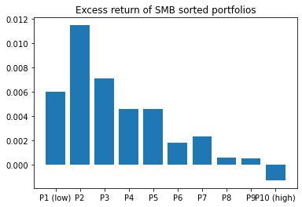

```python
article('SMB', SMB_mon, factors['risk-free'])
```

```
(<BarContainer object of 10 artists>,
                P1 (low)        P2        P3        P4        P5        P6  \
 excess return -0.002241 -0.001319 -0.002465  0.003437 -0.000369  0.001578
 t-stat        -0.551246 -0.340867 -0.842341  1.064894 -0.086682  0.319444
 p-value        0.582498  0.733805  0.401287  0.289080  0.931070  0.749950
 sharpe        -0.050597 -0.031326 -0.077376  0.098138 -0.007963  0.029332

                      P7        P8        P9  P10 (high)
 excess return  0.004986  0.004268  0.007729    0.006011
 t-stat         1.191384  0.818441  1.411412    1.116153
 p-value        0.235873  0.414741  0.160732    0.266605
 sharpe         0.109356  0.075067  0.129492    0.102438  )
```

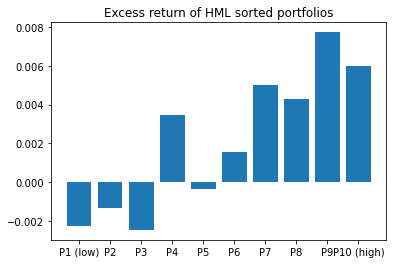

```python
article('HML', HML_mon, factors['risk-free'])
```

```
(<BarContainer object of 10 artists>,
                P1 (low)        P2        P3        P4        P5        P6  \
 excess return -0.003740  0.001131 -0.001900  0.001685  0.001534 -0.000226
 t-stat        -0.764551  0.223228 -0.414917  0.378814  0.353226 -0.061508
 p-value        0.446052  0.823741  0.678950  0.705501  0.724544  0.951058
 sharpe        -0.070245  0.020476 -0.038106  0.034802  0.032425 -0.005649

                      P7        P8        P9  P10 (high)
 excess return  0.000089  0.000460 -0.001778   -0.002455
 t-stat         0.018414  0.111369 -0.454886   -0.708655
 p-value        0.985339  0.911511  0.650020    0.479925
 sharpe         0.001692  0.010229 -0.041832   -0.065055  )
```

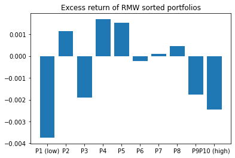

```python
article('RMW', RMW_mon, factors['risk-free'])
```

```
(<BarContainer object of 10 artists>,
                P1 (low)        P2        P3        P4        P5        P6  \
 excess return -0.003169  0.001430  0.004198  0.000269 -0.001852 -0.001630
 t-stat        -0.649305  0.273548  0.917555  0.056450 -0.392137 -0.324329
 p-value        0.517392  0.784906  0.360708  0.955078  0.695659  0.746258
 sharpe        -0.059613  0.025107  0.084228  0.005181 -0.036019 -0.029789

                      P7        P8        P9  P10 (high)
 excess return -0.002784  0.002047  0.000028   -0.002056
 t-stat        -0.652680  0.488139  0.006490   -0.806856
 p-value        0.515221  0.626349  0.994832    0.421359
 sharpe        -0.059983  0.044829  0.000595   -0.074169  )
```

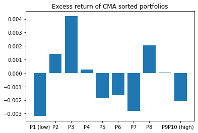

```python
article('CMA', CMA_mon, factors['risk-free'])
```

#### CAPM alpha, Beta

```python
SMB_OLS_data = pd.concat([SMB_mon, factors['Rm']], axis=1)

coef = []
tvalues = []
r = []

for i in range(10):
    model = get_ols_model(SMB, factors['Rm'], SMB_OLS_data.iloc[:,i], cd_91)
    coef.append(model.params)
    tvalues.append(model.tvalues)
    r.append(model.rsquared_adj)
```

```python
pd.concat(coef, axis=1)
```

|  | 0 | 1 | 2 | 3 | 4 | 5 | 6 | 7 | 8 | 9 |
| --- | --- | --- | --- | --- | --- | --- | --- | --- | --- | --- |
| Intercept | 0.006471 | 0.012178 | 0.007846 | 0.005377 | 0.005350 | 0.002554 | 0.003029 | 0.001294 | 0.001240 | -0.000385 |
| market | 0.555788 | 0.821931 | 0.893609 | 0.904471 | 0.904771 | 0.895820 | 0.814204 | 0.854366 | 0.831027 | 1.048933 |

```python
pd.concat(tvalues, axis=1)
```

|  | 0 | 1 | 2 | 3 | 4 | 5 | 6 | 7 | 8 | 9 |
| --- | --- | --- | --- | --- | --- | --- | --- | --- | --- | --- |
| Intercept | 1.705583 | 3.167543 | 2.171983 | 1.492363 | 1.572938 | 0.743149 | 0.960354 | 0.430480 | 0.466219 | -0.298505 |
| market | 6.693773 | 9.768865 | 11.304453 | 11.472179 | 12.155875 | 11.909373 | 11.795623 | 12.983039 | 14.280718 | 37.207777 |

```python
r
```

```
[0.269071415904483,
 0.4424420396366695,
 0.5158481757864919,
 0.5232579770258186,
 0.5522364935536769,
 0.5420138073667053,
 0.5372111904025378,
 0.5847281756882841,
 0.6303646558777123,
 0.9207943802881485]
```

```python
HML_OLS_data = pd.concat([HML_mon, factors['Rm']], axis=1)

coef = []
tvalues = []
r = []

for i in range(10):
    model = get_ols_model(SMB, factors['Rm'], HML_OLS_data.iloc[:,i],cd_91)
    coef.append(model.params)
    tvalues.append(model.tvalues)
    r.append(model.rsquared_adj)
```

```python
pd.concat(coef, axis=1)
```

|  | 0 | 1 | 2 | 3 | 4 | 5 | 6 | 7 | 8 | 9 |
| --- | --- | --- | --- | --- | --- | --- | --- | --- | --- | --- |
| Intercept | -0.001668 | -0.000705 | -0.001995 | 0.003923 | 0.000261 | 0.002319 | 0.005583 | 0.00501 | 0.008455 | 0.006794 |
| market | 0.676728 | 0.725246 | 0.554692 | 0.574052 | 0.745470 | 0.875474 | 0.705949 | 0.87718 | 0.858565 | 0.925990 |

```python
pd.concat(tvalues, axis=1)
```

|  | 0 | 1 | 2 | 3 | 4 | 5 | 6 | 7 | 8 | 9 |
| --- | --- | --- | --- | --- | --- | --- | --- | --- | --- | --- |
| Intercept | -0.570052 | -0.293068 | -1.116893 | 1.813364 | 0.089667 | 0.697315 | 1.876932 | 1.347821 | 2.038271 | 1.810371 |
| market | 10.565915 | 13.771456 | 14.187198 | 12.125353 | 11.694905 | 12.031769 | 10.845705 | 10.783933 | 9.457687 | 11.275063 |

```python
r
```

```
[0.4817943452568685,
 0.6132005964155368,
 0.6272823990941467,
 0.5509843752251391,
 0.5329135188725229,
 0.5471212000007231,
 0.4949694522694814,
 0.49208942976585224,
 0.4263618227324695,
 0.5145374517256782]
```

```python
RMW_OLS_data = pd.concat([RMW_mon, factors['Rm']], axis=1)

coef = []
tvalues = []
r = []

for i in range(10):
    model = get_ols_model(SMB, factors['Rm'], RMW_OLS_data.iloc[:,i], cd_91)
    coef.append(model.params)
    tvalues.append(model.tvalues)
    r.append(model.rsquared_adj)
```

```python
pd.concat(coef, axis=1)
```

|  | 0 | 1 | 2 | 3 | 4 | 5 | 6 | 7 | 8 | 9 |
| --- | --- | --- | --- | --- | --- | --- | --- | --- | --- | --- |
| Intercept | -0.003070 | 0.001885 | -0.001248 | 0.002339 | 0.002182 | 0.000307 | 0.000813 | 0.001128 | -0.001163 | -0.001905 |
| market | 0.792596 | 0.890825 | 0.770808 | 0.774008 | 0.766429 | 0.630329 | 0.856314 | 0.789553 | 0.726666 | 0.650078 |

```python
pd.concat(tvalues, axis=1)
```

|  | 0 | 1 | 2 | 3 | 4 | 5 | 6 | 7 | 8 | 9 |
| --- | --- | --- | --- | --- | --- | --- | --- | --- | --- | --- |
| Intercept | -0.850566 | 0.547243 | -0.382627 | 0.764960 | 0.742946 | 0.119321 | 0.251936 | 0.454206 | -0.472371 | -0.885336 |
| market | 10.035760 | 11.820020 | 10.801871 | 11.564972 | 11.924458 | 11.197387 | 12.126096 | 14.532570 | 13.487951 | 13.802405 |

```python
r
```

```
[0.455916639507427,
 0.5382457936476319,
 0.49292744255234444,
 0.5273061616927621,
 0.5426466402092507,
 0.5110556291525401,
 0.5510148826523888,
 0.6385127706480623,
 0.6032339243724412,
 0.6142705518520581]
```

```python
CMA_OLS_data = pd.concat([CMA_mon, factors['Rm']], axis=1)

coef = []
tvalues = []
r = []

for i in range(10):
    model = get_ols_model(SMB, factors['Rm'], CMA_OLS_data.iloc[:,i], cd_91)
    coef.append(model.params)
    tvalues.append(model.tvalues)
    r.append(model.rsquared_adj)
```

```python
pd.concat(coef, axis=1)
```

|  | 0 | 1 | 2 | 3 | 4 | 5 | 6 | 7 | 8 | 9 |
| --- | --- | --- | --- | --- | --- | --- | --- | --- | --- | --- |
| Intercept | -0.002522 | 0.002191 | 0.004879 | 0.001007 | -0.001120 | -0.000829 | -0.002111 | 0.002679 | 0.000602 | -0.001647 |
| market | 0.764520 | 0.899623 | 0.804794 | 0.871402 | 0.865247 | 0.947828 | 0.795404 | 0.747222 | 0.678413 | 0.483153 |

```python
pd.concat(tvalues, axis=1)
```

|  | 0 | 1 | 2 | 3 | 4 | 5 | 6 | 7 | 8 | 9 |
| --- | --- | --- | --- | --- | --- | --- | --- | --- | --- | --- |
| Intercept | -0.681803 | 0.601851 | 1.569997 | 0.325779 | -0.368164 | -0.267513 | -0.789063 | 0.955558 | 0.188225 | -1.059045 |
| market | 9.444163 | 11.291640 | 11.834250 | 12.888375 | 12.991399 | 13.982208 | 13.585097 | 12.178656 | 9.700548 | 14.193779 |

```python
r
```

```
[0.4256540899005392,
 0.5152771668602183,
 0.5388481285078217,
 0.58114846368766,
 0.5850426394151667,
 0.6204172694723316,
 0.6066828981345,
 0.5531685403995223,
 0.4389455522294041,
 0.627500334764548]
```

### 1. (size/BEME) 25포트폴리오에 대해 OLS분석

# 기간에 따라서 정반대의 결과! 11년 ~ 했을 때는 RMW, CMA, HML가 좋았다 근데, 13년부터 돌리니까, RMW, CMA는 전혀 유의하지 않고, market이랑 SMB가 유효!

```python
# HML pfo
hml_pfo_mask = make_portfolio(get_mask(Market_cap[0], Market_cap[1], breakpoint = [0.2, 0.4, 0.6, 0.8], market_bp='KOSPI'), BEME_shifted, breakpoint = [0.2, 0.4, 0.6, 0.8])

pfo25_hml_pfo = serialize_pfo([get_mask(Market_cap[0], Market_cap[1], breakpoint = [0.2, 0.4, 0.6, 0.8], market_bp='KOSPI'), hml_pfo_mask])

pfo_return_hml_pfo = get_factor_on_date_by_mask(pfo25_hml_pfo, term = 'm', winsorize_limits= 0.01, weight = 'VW')
```

```python
pd.set_option('display.max_columns', None)
pd.set_option('display.max_rows', None)
```

#### 1. (size/BEME) 25포트폴리오에 대해 OLS분석

```
(1) Rm, SMB, HML, RMW, CMA로 regression
```

```python
coef = []
tvalues = []
pvalues = []
se = []
r = []
for i in range(25):
    model = get_ols_model(pfo25_hml_pfo, factors['Rm'], pfo_return_hml_pfo.iloc[:,i], cd_91, factors['SMB'], factors['HML'], factors['RMW'], factors['CMA'])
    coef.append(model.params)
    tvalues.append(model.tvalues)
    pvalues.append(model.pvalues)
    se.append(model.bse)
    r.append(model.rsquared_adj)
```

```python
pd.concat(coef, axis=1)
```

|  | 0 | 1 | 2 | 3 | 4 | 5 | 6 | 7 | 8 | 9 | 10 | 11 | 12 | 13 | 14 | 15 | 16 | 17 | 18 | 19 | 20 | 21 | 22 | 23 | 24 |
| --- | --- | --- | --- | --- | --- | --- | --- | --- | --- | --- | --- | --- | --- | --- | --- | --- | --- | --- | --- | --- | --- | --- | --- | --- | --- |
| Intercept | 0.015071 | 0.008765 | 0.014264 | 0.014938 | 0.009253 | -0.001482 | -0.000547 | 0.000123 | 0.004016 | 0.005027 | -0.003480 | -0.003228 | 0.000507 | 0.002323 | -0.001366 | 0.000109 | -0.002452 | 0.001571 | -0.000036 | -0.001559 | 0.003691 | -0.002796 | 0.004503 | 0.005364 | -0.000521 |
| market | 0.396935 | 0.650940 | 0.717838 | 0.645721 | 0.450448 | 0.579658 | 0.581812 | 0.541126 | 0.596373 | 0.537848 | 0.536767 | 0.619058 | 0.732671 | 0.549170 | 0.455287 | 0.572450 | 0.531108 | 0.613890 | 0.471439 | 0.523164 | 0.727350 | 0.765607 | 1.709112 | 0.747020 | 0.707167 |
| factor0 | 0.870551 | 1.418320 | 1.300617 | 1.450804 | 1.192347 | 1.245038 | 1.184390 | 1.129570 | 1.140948 | 0.941296 | 0.784753 | 1.054177 | 0.915612 | 0.903981 | 0.845025 | 0.602496 | 0.687167 | 0.633604 | 0.550954 | 0.465736 | 0.029905 | -0.026122 | -0.043028 | -0.337872 | -0.194943 |
| factor1 | -0.673763 | 0.021836 | 0.049120 | 0.216895 | 0.255501 | -0.440631 | -0.145501 | 0.066873 | 0.114030 | 0.331357 | -0.642395 | -0.333327 | -0.192387 | 0.241161 | 0.334736 | -0.832680 | -0.438736 | -0.190200 | 0.103222 | 0.455967 | -0.814251 | -0.307978 | 0.151183 | 0.067588 | 0.579394 |
| factor2 | 0.255837 | -0.056645 | 0.296010 | 0.134296 | 0.583250 | -0.059018 | 0.216297 | 0.124514 | 0.316918 | 0.226675 | 0.095749 | 0.179902 | 0.152539 | 0.268558 | 0.364011 | 0.270460 | 0.620491 | 0.754380 | 0.603633 | 0.373112 | 0.617951 | 0.579135 | -0.605842 | 0.066309 | 0.256124 |
| factor3 | 1.709128 | -0.187832 | -0.092038 | -0.162957 | 0.664805 | 0.225102 | 0.431374 | 0.348947 | 0.391869 | 0.298509 | 1.046515 | 0.445879 | 0.370476 | 0.615609 | 0.535804 | 1.083624 | 0.917218 | 1.016471 | 0.958821 | 0.614017 | 1.073591 | 0.496220 | -1.318268 | 0.423876 | 0.619192 |

```python
pd.concat(tvalues, axis=1)
```

|  | 0 | 1 | 2 | 3 | 4 | 5 | 6 | 7 | 8 | 9 | 10 | 11 | 12 | 13 | 14 | 15 | 16 | 17 | 18 | 19 | 20 | 21 | 22 | 23 | 24 |
| --- | --- | --- | --- | --- | --- | --- | --- | --- | --- | --- | --- | --- | --- | --- | --- | --- | --- | --- | --- | --- | --- | --- | --- | --- | --- |
| Intercept | 1.714681 | 2.165766 | 3.410969 | 3.598947 | 2.458947 | -0.428728 | -0.243074 | 0.054359 | 1.676630 | 1.966067 | -0.935860 | -1.211422 | 0.220264 | 0.797414 | -0.513328 | 0.029330 | -0.823861 | 0.493545 | -0.012752 | -0.536433 | 1.009974 | -0.788145 | 1.184114 | 1.822530 | -0.209835 |
| market | 1.803121 | 6.421749 | 6.853474 | 6.211342 | 4.779402 | 6.695739 | 10.331328 | 9.540154 | 9.940196 | 8.398985 | 5.762496 | 9.275824 | 12.710820 | 7.524924 | 6.832534 | 6.153078 | 7.124352 | 7.698394 | 6.632512 | 7.185636 | 7.946702 | 8.615107 | 17.944125 | 10.133365 | 11.368605 |
| factor0 | 2.726624 | 9.647460 | 8.561698 | 9.622221 | 8.722845 | 9.915969 | 14.500887 | 13.730801 | 13.111994 | 10.134907 | 5.808759 | 10.890820 | 10.952231 | 8.540447 | 8.743630 | 4.465137 | 6.355520 | 5.478396 | 5.344334 | 4.410558 | 0.225272 | -0.202668 | -0.311483 | -3.160096 | -2.160822 |
| factor1 | -2.208230 | 0.155426 | 0.338355 | 1.505295 | 1.955933 | -3.672260 | -1.864113 | 0.850625 | 1.371287 | 3.733318 | -4.975748 | -3.603487 | -2.408088 | 2.384151 | 3.624356 | -6.457502 | -4.246172 | -1.720887 | 1.047748 | 4.518487 | -6.418503 | -2.500385 | 1.145211 | 0.661492 | 6.720334 |
| factor2 | 0.472834 | -0.227361 | 1.149822 | 0.525585 | 2.517818 | -0.277364 | 1.562659 | 0.893133 | 2.149137 | 1.440161 | 0.418214 | 1.096726 | 1.076682 | 1.497177 | 2.222548 | 1.182765 | 3.386401 | 3.848928 | 3.455139 | 2.085004 | 2.746871 | 2.651398 | -2.587925 | 0.365962 | 1.675238 |
| factor3 | 2.608068 | -0.622475 | -0.295181 | -0.526565 | 2.369532 | 0.873465 | 2.573160 | 2.066596 | 2.194104 | 1.565900 | 3.774063 | 2.244279 | 2.159056 | 2.833605 | 2.701106 | 3.912661 | 4.133084 | 4.281966 | 4.531362 | 2.833004 | 3.940230 | 1.875721 | -4.649375 | 1.931520 | 3.343874 |

```python
pv = pd.concat(pvalues, axis=1)
pv
```

|  | 0 | 1 | 2 | 3 | 4 | 5 | 6 | 7 | 8 | 9 | 10 | 11 | 12 | 13 | 14 | 15 | 16 | 17 | 18 | 19 | 20 | 21 | 22 | 23 | 24 |
| --- | --- | --- | --- | --- | --- | --- | --- | --- | --- | --- | --- | --- | --- | --- | --- | --- | --- | --- | --- | --- | --- | --- | --- | --- | --- |
| Intercept | 0.089121 | 3.241216e-02 | 8.962776e-04 | 4.741236e-04 | 1.543737e-02 | 6.689302e-01 | 8.083846e-01 | 9.567441e-01 | 9.635513e-02 | 5.172185e-02 | 3.513234e-01 | 2.282390e-01 | 8.260596e-01 | 4.268684e-01 | 6.087154e-01 | 9.766527e-01 | 4.117388e-01 | 6.225769e-01 | 9.898482e-01 | 5.927046e-01 | 3.146465e-01 | 4.322477e-01 | 2.388311e-01 | 7.099563e-02 | 8.341713e-01 |
| market | 0.074011 | 3.214611e-09 | 3.894342e-10 | 8.805306e-09 | 5.286733e-06 | 8.474602e-10 | 4.668435e-18 | 3.282091e-16 | 3.830335e-17 | 1.417498e-13 | 7.171648e-08 | 1.351192e-15 | 1.369870e-23 | 1.324445e-11 | 4.319535e-10 | 1.160849e-08 | 1.008636e-10 | 5.439770e-12 | 1.155065e-09 | 7.411090e-11 | 1.507030e-12 | 4.535773e-14 | 5.374750e-35 | 1.355048e-17 | 1.760601e-20 |
| factor0 | 0.007410 | 1.845829e-16 | 6.014146e-14 | 2.113514e-16 | 2.564883e-14 | 4.363216e-17 | 1.219112e-27 | 6.491820e-26 | 1.651208e-24 | 1.343854e-17 | 5.797677e-08 | 2.296269e-19 | 1.650157e-19 | 6.727972e-14 | 2.297427e-14 | 1.892469e-05 | 4.421389e-09 | 2.597559e-07 | 4.711592e-07 | 2.348784e-05 | 8.221709e-01 | 8.397558e-01 | 7.560026e-01 | 2.020086e-03 | 3.280152e-02 |
| factor1 | 0.029229 | 8.767602e-01 | 7.357179e-01 | 1.350141e-01 | 5.291945e-02 | 3.675351e-04 | 6.487849e-02 | 3.967610e-01 | 1.729789e-01 | 2.965119e-04 | 2.321920e-06 | 4.667524e-04 | 1.763984e-02 | 1.876986e-02 | 4.342441e-04 | 2.704850e-09 | 4.456513e-05 | 8.798429e-02 | 2.969708e-01 | 1.529803e-05 | 3.265333e-09 | 1.382779e-02 | 2.545204e-01 | 5.096313e-01 | 7.510460e-10 |
| factor2 | 0.637236 | 8.205501e-01 | 2.526235e-01 | 6.001976e-01 | 1.319675e-02 | 7.820031e-01 | 1.209045e-01 | 3.736673e-01 | 3.373810e-02 | 1.525624e-01 | 6.765771e-01 | 2.750726e-01 | 2.838955e-01 | 1.371109e-01 | 2.821951e-02 | 2.393633e-01 | 9.723649e-04 | 1.961729e-04 | 7.733529e-04 | 3.930145e-02 | 6.994836e-03 | 9.156879e-03 | 1.091158e-02 | 7.150714e-01 | 9.662842e-02 |
| factor3 | 0.010324 | 5.348727e-01 | 7.683922e-01 | 5.995185e-01 | 1.949112e-02 | 3.842458e-01 | 1.136089e-02 | 4.103741e-02 | 3.025656e-02 | 1.201438e-01 | 2.565858e-04 | 2.674494e-02 | 3.294166e-02 | 5.444919e-03 | 7.965478e-03 | 1.556617e-04 | 6.861391e-05 | 3.881501e-05 | 1.452899e-05 | 5.454473e-03 | 1.407300e-04 | 6.325171e-02 | 9.018025e-06 | 5.590115e-02 | 1.118571e-03 |

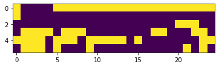

```python
TF =pv>0.05 #False이면 통계적 유의성있음 - 보라색이면 설명력 좋은 것!!
plt.imshow(TF.values)

## 기간에 따라서 정반대가 아니라 계속 설명력 좋다 RMW랑 CMA팩터는 한국시장에서 잘 작동하지 않는다
```

```python
pd.concat(se, axis=1)
```

[output not shown]

```python
r
```

```
[0.33584718020157833,
 0.6674693632044355,
 0.6319604039172082,
 0.6668026244186944,
 0.6914104994847745,
 0.7113566331967238,
 0.8593428899135657,
 0.8524207294843529,
 0.8436021831581562,
 0.7956283735398665,
 0.6809499621206649,
 0.7950888535358689,
 0.8404541647963482,
 0.7764830113783531,
 0.7671752738401504,
 0.6421015251215294,
 0.6888733977871755,
 0.6939558542469342,
 0.7061748207799925,
 0.7028759165280598,
 0.5861596503513213,
 0.5073167341504279,
 0.7450083307061995,
 0.5937466009964874,
 0.7591183388189037]
```

#### 1. (size/BEME) 25포트폴리오에 대해 OLS분석

```
(2) HML를 다른 4개 팩터에 projection시켜서 HMLO로 대체
```

```python
coef_1 = []
tvalues_1 = []
pvalues_1 = []
se_1 = []
r_1 = []
for i in range(25):
    model = get_ols_model(pfo25_hml_pfo, factors['Rm'], pfo_return_hml_pfo.iloc[:,i], cd_91, factors['SMB'], factors['HMLO'], factors['RMW'], factors['CMA'])
    coef_1.append(model.params)
    tvalues_1.append(model.tvalues)
    pvalues_1.append(model.pvalues)
    se_1.append(model.bse)
    r_1.append(model.rsquared_adj)
```

```python
coef_1_table = pd.concat(coef_1, axis=1)
coef_1_table
```

|  | 0 | 1 | 2 | 3 | 4 | 5 | 6 | 7 | 8 | 9 | 10 | 11 | 12 | 13 | 14 | 15 | 16 | 17 | 18 | 19 | 20 | 21 | 22 | 23 | 24 |
| --- | --- | --- | --- | --- | --- | --- | --- | --- | --- | --- | --- | --- | --- | --- | --- | --- | --- | --- | --- | --- | --- | --- | --- | --- | --- |
| Intercept | 0.015040 | 0.008767 | 0.014267 | 0.014948 | 0.009265 | -0.001502 | -0.000553 | 0.000126 | 0.004021 | 0.005042 | -0.003510 | -0.003243 | 0.000498 | 0.002335 | -0.001351 | 0.000070 | -0.002472 | 0.001562 | -0.000031 | -0.001538 | 0.003653 | -0.002811 | 0.004510 | 0.005366 | -0.000495 |
| market | 0.377619 | 0.651566 | 0.719246 | 0.651939 | 0.457773 | 0.567025 | 0.577640 | 0.543044 | 0.599643 | 0.547348 | 0.518350 | 0.609502 | 0.727155 | 0.556084 | 0.464884 | 0.548578 | 0.518529 | 0.608437 | 0.474399 | 0.536236 | 0.704005 | 0.756777 | 1.713446 | 0.748957 | 0.723778 |
| factor0 | 0.821787 | 1.419900 | 1.304172 | 1.466502 | 1.210839 | 1.213147 | 1.173859 | 1.134410 | 1.149201 | 0.965278 | 0.738259 | 1.030052 | 0.901688 | 0.921435 | 0.869252 | 0.542230 | 0.655413 | 0.619838 | 0.558425 | 0.498737 | -0.029028 | -0.048412 | -0.032086 | -0.332980 | -0.153009 |
| factor1 | -0.673877 | 0.021681 | 0.048952 | 0.216920 | 0.255516 | -0.440666 | -0.145467 | 0.066880 | 0.114078 | 0.331385 | -0.642522 | -0.333372 | -0.192409 | 0.241155 | 0.334815 | -0.832662 | -0.438743 | -0.190103 | 0.103190 | 0.456009 | -0.814216 | -0.307941 | 0.151123 | 0.067766 | 0.579493 |
| factor2 | 0.360056 | -0.060023 | 0.288412 | 0.100746 | 0.543729 | 0.009139 | 0.238803 | 0.114170 | 0.299280 | 0.175420 | 0.195115 | 0.231462 | 0.182298 | 0.231255 | 0.312234 | 0.399260 | 0.688355 | 0.783800 | 0.587667 | 0.302582 | 0.743900 | 0.626773 | -0.629227 | 0.055855 | 0.166503 |
| factor3 | 1.501004 | -0.181087 | -0.076865 | -0.095958 | 0.743729 | 0.088992 | 0.386429 | 0.369604 | 0.427093 | 0.400864 | 0.848081 | 0.342915 | 0.311048 | 0.690103 | 0.639204 | 0.826410 | 0.781693 | 0.957718 | 0.990706 | 0.754865 | 0.822070 | 0.401086 | -1.271568 | 0.444753 | 0.798166 |

```python
tvalues_1_table = pd.concat(tvalues_1, axis=1)
tvalues_1_table
```

|  | 0 | 1 | 2 | 3 | 4 | 5 | 6 | 7 | 8 | 9 | 10 | 11 | 12 | 13 | 14 | 15 | 16 | 17 | 18 | 19 | 20 | 21 | 22 | 23 | 24 |
| --- | --- | --- | --- | --- | --- | --- | --- | --- | --- | --- | --- | --- | --- | --- | --- | --- | --- | --- | --- | --- | --- | --- | --- | --- | --- |
| Intercept | 1.711648 | 2.166764 | 3.412591 | 3.602300 | 2.462732 | -0.434712 | -0.246211 | 0.055729 | 1.679199 | 1.972565 | -0.943999 | -1.217483 | 0.216489 | 0.801472 | -0.507776 | 0.018913 | -0.830908 | 0.490753 | -0.011014 | -0.529371 | 0.999838 | -0.792424 | 1.186339 | 1.823811 | -0.199265 |
| market | 1.716721 | 6.432923 | 6.872245 | 6.276056 | 4.860916 | 6.554970 | 10.265169 | 9.581420 | 10.002541 | 8.554074 | 5.569337 | 9.139877 | 12.625025 | 7.625586 | 6.982169 | 5.901000 | 6.961047 | 7.635853 | 6.679326 | 7.371030 | 7.697494 | 8.522323 | 18.003563 | 10.167669 | 11.645452 |
| factor0 | 2.580088 | 9.681385 | 8.605684 | 9.749709 | 8.879409 | 9.685252 | 14.406353 | 13.822751 | 13.238637 | 10.418173 | 5.477953 | 10.667285 | 10.811627 | 8.726235 | 9.016135 | 4.028101 | 6.076391 | 5.372165 | 5.429791 | 4.734488 | -0.219187 | -0.376507 | -0.232830 | -3.121852 | -1.700188 |
| factor1 | -2.208593 | 0.154319 | 0.337191 | 1.505458 | 1.956024 | -3.672540 | -1.863639 | 0.850706 | 1.371853 | 3.733635 | -4.976881 | -3.603986 | -2.408348 | 2.384067 | 3.625255 | -6.457210 | -4.246193 | -1.719964 | 1.047409 | 4.518909 | -6.418032 | -2.500037 | 1.144739 | 0.663229 | 6.721832 |
| factor2 | 0.667994 | -0.241838 | 1.124583 | 0.395790 | 2.356175 | 0.043117 | 1.731832 | 0.822064 | 2.037288 | 1.118785 | 0.855517 | 1.416451 | 1.291649 | 1.294137 | 1.913738 | 1.752671 | 3.771123 | 4.014248 | 3.376581 | 1.697355 | 3.319291 | 2.880431 | -2.698066 | 0.309443 | 1.093278 |
| factor3 | 2.314601 | -0.606437 | -0.249112 | -0.313336 | 2.678741 | 0.348954 | 2.329304 | 2.211974 | 2.416509 | 2.124982 | 3.090762 | 1.744213 | 1.831810 | 3.209924 | 3.256364 | 3.015305 | 3.559471 | 4.076874 | 4.731315 | 3.519566 | 3.048810 | 1.532058 | -4.531850 | 2.048008 | 4.356043 |

```python
pv_1 = pd.concat(pvalues_1, axis=1)
pv_1<0.1 #True이면 통계적 유의성 충분. (설명력 ㅇ)
```

|  | 0 | 1 | 2 | 3 | 4 | 5 | 6 | 7 | 8 | 9 | 10 | 11 | 12 | 13 | 14 | 15 | 16 | 17 | 18 | 19 | 20 | 21 | 22 | 23 | 24 |
| --- | --- | --- | --- | --- | --- | --- | --- | --- | --- | --- | --- | --- | --- | --- | --- | --- | --- | --- | --- | --- | --- | --- | --- | --- | --- |
| Intercept | True | True | True | True | True | False | False | False | True | True | False | False | False | False | False | False | False | False | False | False | False | False | False | True | False |
| market | True | True | True | True | True | True | True | True | True | True | True | True | True | True | True | True | True | True | True | True | True | True | True | True | True |
| factor0 | True | True | True | True | True | True | True | True | True | True | True | True | True | True | True | True | True | True | True | True | False | False | False | True | True |
| factor1 | True | False | False | False | True | True | True | False | False | True | True | True | True | True | True | True | True | True | False | True | True | True | False | False | True |
| factor2 | False | False | False | False | True | False | True | False | True | False | False | False | False | False | True | True | True | True | True | True | True | True | True | False | False |
| factor3 | True | False | False | False | True | False | True | True | True | True | True | True | True | True | True | True | True | True | True | True | True | False | True | True | True |

```python
TF_1 =pv_1<0.05 #노란색이 좋은 것
TF_1
```

|  | 0 | 1 | 2 | 3 | 4 | 5 | 6 | 7 | 8 | 9 | 10 | 11 | 12 | 13 | 14 | 15 | 16 | 17 | 18 | 19 | 20 | 21 | 22 | 23 | 24 |
| --- | --- | --- | --- | --- | --- | --- | --- | --- | --- | --- | --- | --- | --- | --- | --- | --- | --- | --- | --- | --- | --- | --- | --- | --- | --- |
| Intercept | False | True | True | True | True | False | False | False | False | False | False | False | False | False | False | False | False | False | False | False | False | False | False | False | False |
| market | False | True | True | True | True | True | True | True | True | True | True | True | True | True | True | True | True | True | True | True | True | True | True | True | True |
| factor0 | True | True | True | True | True | True | True | True | True | True | True | True | True | True | True | True | True | True | True | True | False | False | False | True | False |
| factor1 | True | False | False | False | False | True | False | False | False | True | True | True | True | True | True | True | True | False | False | True | True | True | False | False | True |
| factor2 | False | False | False | False | True | False | False | False | True | False | False | False | False | False | False | False | True | True | True | False | True | True | True | False | False |
| factor3 | True | False | False | False | True | False | True | True | True | True | True | False | False | True | True | True | True | True | True | True | True | False | True | True | True |

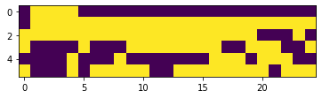

```python
plt.imshow(TF_1.values)
```

```python
shaped_r1= reshape(pd.Series(r_1), 'B/M', 5,'Size',5)
shaped_r1
```

| B/M Size | 1 | 2 | 3 | 4 | 5 |
| --- | --- | --- | --- | --- | --- |
| 1 | 0.335856 | 0.667468 | 0.631958 | 0.666804 | 0.691411 |
| 2 | 0.711361 | 0.859341 | 0.852421 | 0.843604 | 0.795632 |
| 3 | 0.680976 | 0.795095 | 0.840456 | 0.776482 | 0.767187 |
| 4 | 0.642093 | 0.688874 | 0.693948 | 0.706173 | 0.702884 |
| 5 | 0.586144 | 0.507310 | 0.745006 | 0.593755 | 0.759149 |

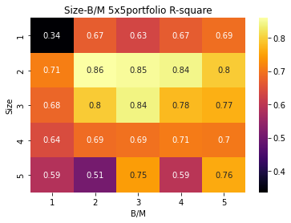

```python
os.chdir('C:\\Users\\jky93\\KYdrive\\바탕 화면\\창업\\아티클')
sns.heatmap(shaped_r1, cmap = 'inferno', annot=True)
plt.title('Size-B/M 5x5portfolio R-square')
plt.savefig('r1.png', dpi=400)
```

```python
shaped_int_coef1 = reshape(coef_1_table.loc['Intercept',:], 'B/M', 5,'Size',5)
shaped_mkt_coef1 = reshape(coef_1_table.loc['market',:], 'B/M', 5,'Size',5)
shaped_SMB_coef1 = reshape(coef_1_table.loc['factor0',:], 'B/M', 5,'Size',5)
shaped_HMLO_coef1 = reshape(coef_1_table.loc['factor1',:], 'B/M', 5,'Size',5)
shaped_RMW_coef1 = reshape(coef_1_table.loc['factor2',:], 'B/M', 5,'Size',5)
shaped_CMA_coef1 = reshape(coef_1_table.loc['factor3',:], 'B/M', 5,'Size',5)
```

```python
shaped_mkt_t
```

[output not shown]

```python
shaped_int_t = reshape(tvalues_1_table.loc['Intercept',:], 'B/M', 5,'Size',5)
shaped_mkt_t = reshape(tvalues_1_table.loc['market',:], 'B/M', 5,'Size',5)
shaped_SMB_t = reshape(tvalues_1_table.loc['factor0',:], 'B/M', 5,'Size',5)
shaped_HMLO_t = reshape(tvalues_1_table.loc['factor1',:], 'B/M', 5,'Size',5)
shaped_RMW_t = reshape(tvalues_1_table.loc['factor2',:], 'B/M', 5,'Size',5)
shaped_CMA_t = reshape(tvalues_1_table.loc['factor3',:], 'B/M', 5,'Size',5)
```

```python
def graph(data:list, figsize:tuple, name:str):
    os.chdir('C:\\Users\\jky93\\KYdrive\\바탕 화면\\창업\\아티클')
    fig = plt.figure(figsize=(15,15))
    ax0 = fig.add_subplot(131, projection='3d')
    ax1 = fig.add_subplot(132, projection='3d')
    ax2 = fig.add_subplot(133, projection='3d')
    axs = [ax0, ax1, ax2]

    fontlabel = {"fontsize":"large", "color":"gray", "fontweight":"bold"}
    for ax, datum in zip(axs, data):
        data_pt = datum
        X_ = data_pt.columns.tolist() #B/M
        Y_ = data_pt.index.tolist()     #Size
        X = [X_ for _ in range(len(Y_))]
        Y = [[y_]*len(X_) for y_ in Y_]
        Z = data_pt.values

        ax.set_xlabel(datum.columns.name, fontdict=fontlabel, labelpad=16)
        ax.set_ylabel("Size", fontdict=fontlabel, labelpad=16)
    #     ax.set_title("Z", fontdict=fontlabel)
        ax.view_init(elev=25, azim=140)

        ax.contourf(X, Y, Z, cmap="inferno", alpha=0.7)
        ax.scatter(X, Y, Z, color='black', s=10, alpha=1)
    plt.savefig(name + ' coefficients.png', dpi=400)
```

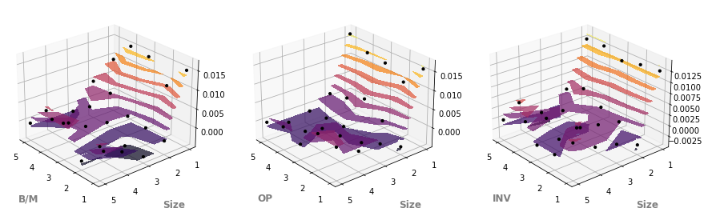

```python
graph([shaped_int_coef1, shaped_int_coef2, shaped_int_coef3], (15,15), 'Intercept')
```

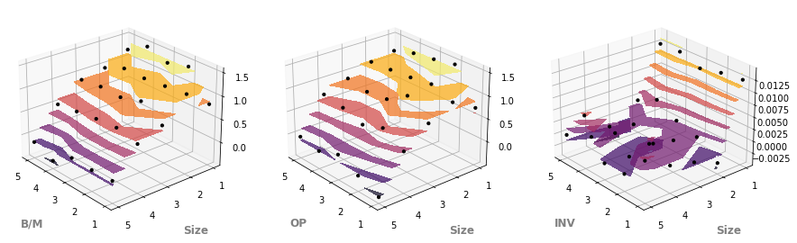

```python
graph([shaped_SMB_coef1, shaped_SMB_coef2, shaped_int_coef3], (15,15), 'SMB')
```

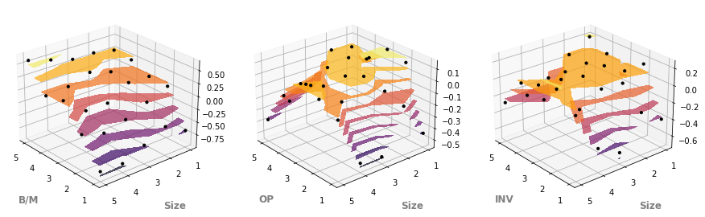

```python
graph([shaped_HMLO_coef1, shaped_HMLO_coef2, shaped_HMLO_coef3], (15,15), 'HMLO')
```

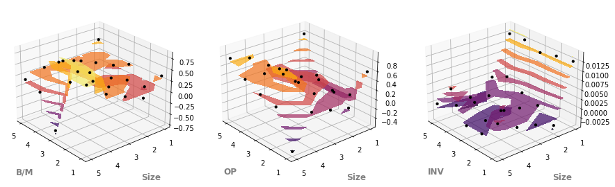

```python
graph([shaped_RMW_coef1, shaped_RMW_coef2, shaped_int_coef3], (15,15), 'RMW')
```

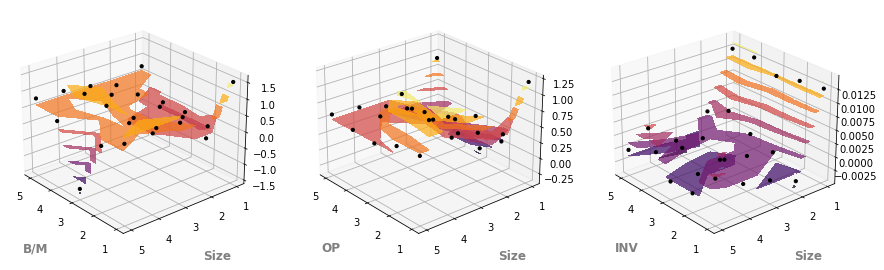

```python
graph([shaped_CMA_coef1, shaped_CMA_coef2, shaped_int_coef3], (15,15), 'CMA')
```

### 2. (size/OP) 25포트폴리오에 대해 OLS분석

```python
# OP pfo
rmw_pfo_mask = make_portfolio(get_mask(Market_cap[0], Market_cap[1], breakpoint = [0.2, 0.4, 0.6, 0.8], market_bp='KOSPI'), RMW_base_shifted, breakpoint = [0.2, 0.4, 0.6, 0.8])

pfo25_rmw_pfo = serialize_pfo([get_mask(Market_cap[0], Market_cap[1], breakpoint = [0.2, 0.4, 0.6, 0.8], market_bp='KOSPI'), rmw_pfo_mask])

pfo_return_rmw_pfo = get_factor_on_date_by_mask(pfo25_rmw_pfo, term = 'm', winsorize_limits= 0.01, weight = 'VW')
```

#### 2. (size/OP) 25포트폴리오에 대해 OLS분석

```
(1) Rm, SMB, HML, RMW(OP), CMA(Inv)로 regression
```

```python
coef = []
tvalues = []
pvalues = []
se = []
r = []
for i in range(25):
    model = get_ols_model(pfo25_rmw_pfo, factors['Rm'], pfo_return_rmw_pfo.iloc[:,i], cd_91, factors['SMB'], factors['HML'], factors['RMW'], factors['CMA'])
    coef.append(model.params)
    tvalues.append(model.tvalues)
    pvalues.append(model.pvalues)
    se.append(model.bse)
    r.append(model.rsquared_adj)
```

```python
pd.concat(coef, axis=1)
```

|  | 0 | 1 | 2 | 3 | 4 | 5 | 6 | 7 | 8 | 9 | 10 | 11 | 12 | 13 | 14 | 15 | 16 | 17 | 18 | 19 | 20 | 21 | 22 | 23 | 24 |
| --- | --- | --- | --- | --- | --- | --- | --- | --- | --- | --- | --- | --- | --- | --- | --- | --- | --- | --- | --- | --- | --- | --- | --- | --- | --- |
| Intercept | 0.015578 | 0.009854 | 0.012737 | 0.013365 | 0.016442 | -0.003061 | 0.001408 | 0.004912 | 0.002773 | 0.001614 | -0.000014 | -0.002375 | -0.000565 | -0.000756 | -0.001241 | 0.000284 | 0.001680 | 0.001054 | -0.002300 | -0.002318 | 0.003576 | 0.004435 | -0.001018 | 0.001091 | -0.000197 |
| market | 0.506428 | 0.472383 | 0.719053 | 0.610477 | 0.497071 | 0.442427 | 0.674397 | 0.615922 | 0.541051 | 0.604977 | 0.422811 | 0.673113 | 0.518620 | 0.658594 | 0.633351 | 0.645820 | 0.502857 | 0.462982 | 0.544208 | 0.523766 | 0.770436 | 0.748913 | 0.719084 | 0.732665 | 0.746700 |
| factor0 | 0.766488 | 1.461584 | 1.373842 | 1.320386 | 1.181070 | 1.049338 | 1.220215 | 1.145014 | 1.115702 | 1.092796 | 0.811546 | 1.135077 | 0.853293 | 0.802582 | 0.905964 | 0.409069 | 0.643099 | 0.484241 | 0.636029 | 0.729630 | -0.391371 | -0.188987 | 0.020997 | -0.128670 | -0.023520 |
| factor1 | -0.445184 | 0.081097 | 0.123022 | -0.016253 | 0.011551 | -0.148447 | -0.099071 | 0.099279 | 0.041813 | 0.040189 | -0.506209 | 0.085433 | 0.016060 | 0.016121 | -0.209401 | -0.487971 | -0.060565 | -0.006341 | -0.063903 | -0.283432 | -0.063403 | 0.023707 | 0.075612 | -0.097706 | -0.379226 |
| factor2 | 0.519279 | -0.059031 | -0.165702 | -0.072831 | 0.803872 | -0.064458 | 0.149180 | 0.343832 | 0.139890 | 0.132686 | -0.015743 | 0.249571 | 0.311228 | 0.326543 | 0.327089 | 0.093667 | 0.622194 | 0.729840 | 0.460017 | 0.605381 | -0.505321 | 0.251661 | 0.346054 | 0.468081 | 0.709468 |
| factor3 | 1.328682 | 0.171708 | -0.255212 | -0.142689 | 0.932835 | 0.462309 | 0.402670 | 0.380794 | 0.216963 | 0.225906 | 1.113733 | 0.420147 | 0.539224 | 0.551669 | 0.484562 | 1.242243 | 1.007241 | 1.094172 | 0.593953 | 0.632674 | 0.682613 | 0.617467 | 0.457640 | 0.541202 | 0.694139 |

```python
pd.concat(tvalues, axis=1)
```

|  | 0 | 1 | 2 | 3 | 4 | 5 | 6 | 7 | 8 | 9 | 10 | 11 | 12 | 13 | 14 | 15 | 16 | 17 | 18 | 19 | 20 | 21 | 22 | 23 | 24 |
| --- | --- | --- | --- | --- | --- | --- | --- | --- | --- | --- | --- | --- | --- | --- | --- | --- | --- | --- | --- | --- | --- | --- | --- | --- | --- |
| Intercept | 1.773579 | 2.135484 | 2.894438 | 3.426550 | 3.217473 | -0.939499 | 0.542286 | 2.072386 | 1.225887 | 0.570505 | -0.003846 | -0.897738 | -0.229742 | -0.314977 | -0.455216 | 0.079472 | 0.565360 | 0.356101 | -0.808673 | -0.758800 | 1.284157 | 1.614036 | -0.335721 | 0.327253 | -0.070521 |
| market | 2.302051 | 4.087223 | 6.523896 | 6.248939 | 3.883631 | 5.421940 | 10.370859 | 10.374182 | 9.548417 | 8.535716 | 4.488226 | 10.160046 | 8.424532 | 10.952365 | 9.272327 | 7.214249 | 6.754739 | 6.243704 | 7.638858 | 6.845964 | 11.047099 | 10.881747 | 9.463720 | 8.772476 | 10.657418 |
| factor0 | 2.402307 | 8.719335 | 8.594274 | 9.318890 | 6.362401 | 8.866549 | 12.937844 | 13.297343 | 13.575867 | 10.630806 | 5.939744 | 11.812977 | 9.556985 | 9.202499 | 9.144959 | 3.150663 | 5.956181 | 4.502628 | 6.155552 | 6.575465 | -3.869244 | -1.893329 | 0.190534 | -1.062236 | -0.231461 |
| factor1 | -1.460051 | 0.506255 | 0.805308 | -0.120034 | 0.065113 | -1.312548 | -1.099204 | 1.206477 | 0.532397 | 0.409106 | -3.876949 | 0.930392 | 0.188229 | 0.193426 | -2.211850 | -3.932829 | -0.586974 | -0.061700 | -0.647170 | -2.672874 | -0.655920 | 0.248528 | 0.717968 | -0.844056 | -3.905131 |
| factor2 | 0.960368 | -0.207806 | -0.611668 | -0.303314 | 2.555326 | -0.321390 | 0.933361 | 2.356216 | 1.004433 | 0.761668 | -0.067991 | 1.532648 | 2.056912 | 2.209386 | 1.948277 | 0.425704 | 3.400406 | 4.004481 | 2.627109 | 3.219339 | -2.947946 | 1.487730 | 1.852963 | 2.280228 | 4.119828 |
| factor3 | 2.028883 | 0.499073 | -0.777832 | -0.490643 | 2.448291 | 1.903200 | 2.080118 | 2.154551 | 1.286226 | 1.070698 | 3.971444 | 2.130338 | 2.942422 | 3.081825 | 2.383049 | 4.661495 | 4.545030 | 4.956816 | 2.800625 | 2.777900 | 3.287949 | 3.013838 | 2.023231 | 2.176784 | 3.328063 |

```python
pv = pd.concat(pvalues, axis=1)
pv
```

|  | 0 | 1 | 2 | 3 | 4 | 5 | 6 | 7 | 8 | 9 | 10 | 11 | 12 | 13 | 14 | 15 | 16 | 17 | 18 | 19 | 20 | 21 | 22 | 23 | 24 |
| --- | --- | --- | --- | --- | --- | --- | --- | --- | --- | --- | --- | --- | --- | --- | --- | --- | --- | --- | --- | --- | --- | --- | --- | --- | --- |
| Intercept | 0.078803 | 3.486164e-02 | 4.552732e-03 | 8.509586e-04 | 1.683885e-03 | 3.494612e-01 | 5.886797e-01 | 4.048439e-02 | 2.227677e-01 | 5.694579e-01 | 9.969380e-01 | 3.712172e-01 | 8.187043e-01 | 7.533551e-01 | 6.498199e-01 | 9.367962e-01 | 5.729399e-01 | 7.224229e-01 | 4.203879e-01 | 4.495381e-01 | 2.016907e-01 | 1.092843e-01 | 7.376985e-01 | 7.440766e-01 | 9.439027e-01 |
| market | 0.023148 | 8.156095e-05 | 1.960801e-09 | 7.362390e-09 | 1.730117e-04 | 3.341052e-07 | 3.773443e-18 | 3.706526e-18 | 3.139881e-16 | 6.898046e-14 | 1.726336e-05 | 1.173808e-17 | 1.239245e-13 | 1.648962e-19 | 1.376687e-15 | 6.415827e-11 | 6.341111e-10 | 7.548369e-09 | 7.387619e-12 | 4.041852e-10 | 9.906340e-20 | 2.411162e-19 | 4.943599e-16 | 1.971659e-14 | 8.065714e-19 |
| factor0 | 0.017907 | 2.613012e-14 | 5.063621e-14 | 1.073286e-15 | 4.277647e-09 | 1.196757e-14 | 4.130361e-24 | 6.240955e-25 | 1.454814e-25 | 9.308271e-19 | 3.160790e-08 | 1.627408e-21 | 2.998900e-16 | 1.999188e-15 | 2.717975e-15 | 2.081000e-03 | 2.927761e-08 | 1.629942e-05 | 1.147335e-08 | 1.525838e-09 | 1.822788e-04 | 6.084930e-02 | 8.492296e-01 | 2.903736e-01 | 8.173718e-01 |
| factor1 | 0.147026 | 6.136554e-01 | 4.223183e-01 | 9.046678e-01 | 9.481983e-01 | 1.919716e-01 | 2.739951e-01 | 2.301315e-01 | 5.954872e-01 | 6.832292e-01 | 1.772585e-04 | 3.541344e-01 | 8.510320e-01 | 8.469699e-01 | 2.897120e-02 | 1.445988e-04 | 5.583818e-01 | 9.509101e-01 | 5.188230e-01 | 8.623645e-03 | 5.131971e-01 | 8.041730e-01 | 4.742460e-01 | 4.004058e-01 | 1.599952e-04 |
| factor2 | 0.338902 | 8.357515e-01 | 5.419755e-01 | 7.622032e-01 | 1.192574e-02 | 7.485033e-01 | 3.526064e-01 | 2.016936e-02 | 3.172974e-01 | 4.478312e-01 | 9.459119e-01 | 1.281331e-01 | 4.197680e-02 | 2.914675e-02 | 5.383966e-02 | 6.711262e-01 | 9.282802e-04 | 1.110547e-04 | 9.795742e-03 | 1.673879e-03 | 3.881052e-03 | 1.395830e-01 | 6.647386e-02 | 2.445334e-02 | 7.213840e-05 |
| factor3 | 0.044800 | 6.186896e-01 | 4.382791e-01 | 6.246221e-01 | 1.587739e-02 | 5.953643e-02 | 3.975592e-02 | 3.330130e-02 | 2.009702e-01 | 2.865668e-01 | 1.254753e-04 | 3.529347e-02 | 3.945909e-03 | 2.579910e-03 | 1.882339e-02 | 8.583349e-06 | 1.375354e-05 | 2.515748e-06 | 5.992902e-03 | 6.399312e-03 | 1.342301e-03 | 3.179487e-03 | 4.538874e-02 | 3.155869e-02 | 1.177999e-03 |

```python
pv<0.1
```

|  | 0 | 1 | 2 | 3 | 4 | 5 | 6 | 7 | 8 | 9 | 10 | 11 | 12 | 13 | 14 | 15 | 16 | 17 | 18 | 19 | 20 | 21 | 22 | 23 | 24 |
| --- | --- | --- | --- | --- | --- | --- | --- | --- | --- | --- | --- | --- | --- | --- | --- | --- | --- | --- | --- | --- | --- | --- | --- | --- | --- |
| Intercept | True | True | True | True | True | False | False | True | False | False | False | False | False | False | False | False | False | False | False | False | False | False | False | False | False |
| market | True | True | True | True | True | True | True | True | True | True | True | True | True | True | True | True | True | True | True | True | True | True | True | True | True |
| factor0 | True | True | True | True | True | True | True | True | True | True | True | True | True | True | True | True | True | True | True | True | True | True | False | False | False |
| factor1 | False | False | False | False | False | False | False | False | False | False | True | False | False | False | True | True | False | False | False | True | False | False | False | False | True |
| factor2 | False | False | False | False | True | False | False | True | False | False | False | False | True | True | True | False | True | True | True | True | True | False | True | True | True |
| factor3 | True | False | False | False | True | True | True | True | False | False | True | True | True | True | True | True | True | True | True | True | True | True | True | True | True |

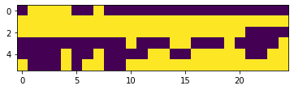

```python
TF =pv<0.05
plt.imshow(TF.values)
```

```python
r
```

```
[0.2578147716160414,
 0.6321274171383615,
 0.6448999888925913,
 0.6562265189155313,
 0.5546114866192593,
 0.7140913509404672,
 0.8430330465364406,
 0.8467858540273662,
 0.8356749612578432,
 0.7754439860679773,
 0.6835393653416698,
 0.8323522826030997,
 0.7856548954795439,
 0.8173084972728966,
 0.7644254549883429,
 0.6996751651438846,
 0.7080388490907327,
 0.6717161907363975,
 0.6759988818156604,
 0.6402714492976003,
 0.7412688932914497,
 0.6575691562629538,
 0.5883969391023971,
 0.5194558105688671,
 0.6444397166406628]
```

#### 2. (size/OP) 25포트폴리오에 대해 OLS분석

```
(2) HML를 다른 4개 팩터에 projection시켜서 HMLO로 대체
```

```python
coef_2 = []
tvalues_2 = []
pvalues_2 = []
se_2 = []
r_2 = []
for i in range(25):
    model = get_ols_model(pfo25_rmw_pfo, factors['Rm'], pfo_return_rmw_pfo.iloc[:,i], cd_91, factors['SMB'], factors['HMLO'], factors['RMW'], factors['CMA'])
    coef_2.append(model.params)
    tvalues_2.append(model.tvalues)
    pvalues_2.append(model.pvalues)
    se_2.append(model.bse)
    r_2.append(model.rsquared_adj)
```

```python
coef_2_table = pd.concat(coef_2, axis=1)
coef_2_table
```

|  | 0 | 1 | 2 | 3 | 4 | 5 | 6 | 7 | 8 | 9 | 10 | 11 | 12 | 13 | 14 | 15 | 16 | 17 | 18 | 19 | 20 | 21 | 22 | 23 | 24 |
| --- | --- | --- | --- | --- | --- | --- | --- | --- | --- | --- | --- | --- | --- | --- | --- | --- | --- | --- | --- | --- | --- | --- | --- | --- | --- |
| Intercept | 0.015559 | 0.009858 | 0.012743 | 0.013364 | 0.016443 | -0.003068 | 0.001403 | 0.004917 | 0.002775 | 0.001616 | -0.000038 | -0.002370 | -0.000564 | -0.000755 | -0.001251 | 0.000261 | 0.001677 | 0.001054 | -0.002303 | -0.002331 | 0.003573 | 0.004435 | -0.001016 | 0.001086 | -0.000215 |
| market | 0.493665 | 0.474708 | 0.722580 | 0.610011 | 0.497403 | 0.438171 | 0.671556 | 0.618768 | 0.542250 | 0.606129 | 0.408298 | 0.675562 | 0.519080 | 0.659056 | 0.627347 | 0.631830 | 0.501120 | 0.462800 | 0.542376 | 0.515640 | 0.768618 | 0.749593 | 0.721252 | 0.729864 | 0.735828 |
| factor0 | 0.734268 | 1.467453 | 1.382746 | 1.319210 | 1.181906 | 1.038594 | 1.213045 | 1.152199 | 1.118728 | 1.095704 | 0.774909 | 1.141261 | 0.854455 | 0.803749 | 0.890809 | 0.373751 | 0.638715 | 0.483782 | 0.631404 | 0.709117 | -0.395959 | -0.187272 | 0.026470 | -0.135742 | -0.050967 |
| factor1 | -0.445485 | 0.081084 | 0.122961 | -0.016227 | 0.011439 | -0.148479 | -0.099086 | 0.099306 | 0.041839 | 0.040208 | -0.506173 | 0.085368 | 0.016083 | 0.016123 | -0.209458 | -0.487845 | -0.060526 | -0.006344 | -0.063908 | -0.283473 | -0.063381 | 0.023842 | 0.075727 | -0.097515 | -0.379263 |
| factor2 | 0.588140 | -0.071576 | -0.184732 | -0.070317 | 0.802085 | -0.041496 | 0.164504 | 0.328476 | 0.133422 | 0.126469 | 0.062558 | 0.236356 | 0.308744 | 0.324050 | 0.359479 | 0.169147 | 0.631563 | 0.730821 | 0.469902 | 0.649223 | -0.495514 | 0.247994 | 0.334358 | 0.483195 | 0.768127 |
| factor3 | 1.191166 | 0.196759 | -0.217210 | -0.147709 | 0.936403 | 0.416454 | 0.372067 | 0.411461 | 0.229879 | 0.238320 | 0.957365 | 0.446537 | 0.544185 | 0.556649 | 0.419878 | 1.091510 | 0.988533 | 1.092213 | 0.574213 | 0.545122 | 0.663028 | 0.624790 | 0.480997 | 0.511021 | 0.576997 |

```python
tvalues_2_table = pd.concat(tvalues_2, axis=1)
tvalues_2_table
```

|  | 0 | 1 | 2 | 3 | 4 | 5 | 6 | 7 | 8 | 9 | 10 | 11 | 12 | 13 | 14 | 15 | 16 | 17 | 18 | 19 | 20 | 21 | 22 | 23 | 24 |
| --- | --- | --- | --- | --- | --- | --- | --- | --- | --- | --- | --- | --- | --- | --- | --- | --- | --- | --- | --- | --- | --- | --- | --- | --- | --- |
| Intercept | 1.771878 | 2.136875 | 2.896555 | 3.427229 | 3.218528 | -0.941817 | 0.540686 | 2.074829 | 1.227016 | 0.571283 | -0.010137 | -0.896355 | -0.229543 | -0.314753 | -0.458805 | 0.072990 | 0.564500 | 0.356101 | -0.809920 | -0.763249 | 1.283401 | 1.614636 | -0.334834 | 0.325706 | -0.076768 |
| market | 2.245809 | 4.110538 | 6.560985 | 6.249033 | 3.889245 | 5.373984 | 10.335241 | 10.430278 | 9.577043 | 8.558641 | 4.337498 | 10.204901 | 8.438585 | 10.968591 | 9.191693 | 7.063213 | 6.736646 | 6.246115 | 7.619075 | 6.745059 | 11.029606 | 10.900143 | 9.499710 | 8.745637 | 10.510545 |
| factor0 | 2.306876 | 8.775366 | 8.670716 | 9.332941 | 6.382189 | 8.796864 | 12.892716 | 13.412960 | 13.645394 | 10.684701 | 5.685149 | 11.905775 | 9.592985 | 9.238004 | 9.013665 | 2.885454 | 5.929774 | 4.509160 | 6.125463 | 6.405992 | -3.924004 | -1.880650 | 0.240771 | -1.123292 | -0.502771 |
| factor1 | -1.461039 | 0.506168 | 0.804896 | -0.119841 | 0.064481 | -1.312824 | -1.099356 | 1.206796 | 0.532720 | 0.409299 | -3.876587 | 0.929666 | 0.188494 | 0.193451 | -2.212452 | -3.931627 | -0.586585 | -0.061730 | -0.647213 | -2.673251 | -0.655688 | 0.249945 | 0.719060 | -0.842382 | -3.905519 |
| factor2 | 1.091889 | -0.252926 | -0.684513 | -0.293962 | 2.559380 | -0.207692 | 1.033171 | 2.259582 | 0.961653 | 0.728755 | 0.271208 | 1.457027 | 2.048285 | 2.200885 | 2.149407 | 0.771655 | 3.464776 | 4.025172 | 2.693805 | 3.465694 | -2.901766 | 1.471654 | 1.797185 | 2.362810 | 4.477539 |
| factor3 | 1.838064 | 0.577902 | -0.668978 | -0.513252 | 2.483522 | 1.732478 | 1.942262 | 2.352579 | 1.377142 | 1.141426 | 3.449750 | 2.287965 | 3.000749 | 3.142373 | 2.086696 | 4.138829 | 4.507550 | 5.000020 | 2.736047 | 2.418696 | 3.227223 | 3.081689 | 2.148886 | 2.076998 | 2.795572 |

```python
pv_2 = pd.concat(pvalues_2, axis=1)
pv_2
```

|  | 0 | 1 | 2 | 3 | 4 | 5 | 6 | 7 | 8 | 9 | 10 | 11 | 12 | 13 | 14 | 15 | 16 | 17 | 18 | 19 | 20 | 21 | 22 | 23 | 24 |
| --- | --- | --- | --- | --- | --- | --- | --- | --- | --- | --- | --- | --- | --- | --- | --- | --- | --- | --- | --- | --- | --- | --- | --- | --- | --- |
| Intercept | 0.079087 | 3.474570e-02 | 4.524240e-03 | 8.490346e-04 | 1.678220e-03 | 3.482780e-01 | 5.897788e-01 | 4.025297e-02 | 2.223447e-01 | 5.689325e-01 | 9.919297e-01 | 3.719519e-01 | 8.188584e-01 | 7.535247e-01 | 6.472474e-01 | 9.419417e-01 | 5.735227e-01 | 7.224232e-01 | 4.196733e-01 | 4.468914e-01 | 2.019544e-01 | 1.091541e-01 | 7.383657e-01 | 7.452439e-01 | 9.389430e-01 |
| market | 0.026644 | 7.471114e-05 | 1.637307e-09 | 7.359097e-09 | 1.695191e-04 | 4.133032e-07 | 4.571122e-18 | 2.740258e-18 | 2.693087e-16 | 6.111985e-14 | 3.128167e-05 | 9.220411e-18 | 1.150897e-13 | 1.511129e-19 | 2.117929e-15 | 1.370480e-10 | 6.931654e-10 | 7.462147e-09 | 8.177255e-12 | 6.650589e-10 | 1.088350e-19 | 2.183921e-19 | 4.076586e-16 | 2.273109e-14 | 1.778641e-18 |
| factor0 | 0.022868 | 1.941675e-14 | 3.380103e-14 | 9.955863e-16 | 3.889467e-09 | 1.732440e-14 | 5.240206e-24 | 3.406767e-25 | 1.012563e-25 | 6.963854e-19 | 1.021450e-07 | 9.909486e-22 | 2.472389e-16 | 1.653829e-15 | 5.472586e-15 | 4.675448e-03 | 3.310924e-08 | 1.587947e-05 | 1.322779e-08 | 3.468325e-09 | 1.493437e-04 | 6.257131e-02 | 8.101652e-01 | 2.636734e-01 | 6.160954e-01 |
| factor1 | 0.146755 | 6.137159e-01 | 4.225550e-01 | 9.048199e-01 | 9.487004e-01 | 1.918789e-01 | 2.739292e-01 | 2.300090e-01 | 5.952640e-01 | 6.830883e-01 | 1.774914e-04 | 3.545084e-01 | 8.508244e-01 | 8.469499e-01 | 2.892845e-02 | 1.452364e-04 | 5.586425e-01 | 9.508858e-01 | 5.187955e-01 | 8.614532e-03 | 5.133462e-01 | 8.030796e-01 | 4.735753e-01 | 4.013380e-01 | 1.597693e-04 |
| factor2 | 0.277184 | 8.007808e-01 | 4.950405e-01 | 7.693213e-01 | 1.179517e-02 | 8.358397e-01 | 3.037107e-01 | 2.574745e-02 | 3.382593e-01 | 4.676459e-01 | 7.867215e-01 | 1.478579e-01 | 4.282911e-02 | 2.975963e-02 | 3.371620e-02 | 4.419152e-01 | 7.487291e-04 | 1.028447e-04 | 8.131151e-03 | 7.464238e-04 | 4.454830e-03 | 1.438696e-01 | 7.495382e-02 | 1.983097e-02 | 1.801403e-05 |
| factor3 | 0.068657 | 5.644700e-01 | 5.048621e-01 | 6.087683e-01 | 1.446376e-02 | 8.589304e-02 | 5.457214e-02 | 2.035819e-02 | 1.711664e-01 | 2.560849e-01 | 7.874523e-04 | 2.398332e-02 | 3.308761e-03 | 2.135935e-03 | 3.914514e-02 | 6.713823e-05 | 1.598201e-05 | 2.094570e-06 | 7.214154e-03 | 1.715866e-02 | 1.632223e-03 | 2.581002e-03 | 3.375844e-02 | 4.004851e-02 | 6.081177e-03 |

```python
pv_2<0.1
```

|  | 0 | 1 | 2 | 3 | 4 | 5 | 6 | 7 | 8 | 9 | 10 | 11 | 12 | 13 | 14 | 15 | 16 | 17 | 18 | 19 | 20 | 21 | 22 | 23 | 24 |
| --- | --- | --- | --- | --- | --- | --- | --- | --- | --- | --- | --- | --- | --- | --- | --- | --- | --- | --- | --- | --- | --- | --- | --- | --- | --- |
| Intercept | True | True | True | True | True | False | False | True | False | False | False | False | False | False | False | False | False | False | False | False | False | False | False | False | False |
| market | True | True | True | True | True | True | True | True | True | True | True | True | True | True | True | True | True | True | True | True | True | True | True | True | True |
| factor0 | True | True | True | True | True | True | True | True | True | True | True | True | True | True | True | True | True | True | True | True | True | True | False | False | False |
| factor1 | False | False | False | False | False | False | False | False | False | False | True | False | False | False | True | True | False | False | False | True | False | False | False | False | True |
| factor2 | False | False | False | False | True | False | False | True | False | False | False | False | True | True | True | False | True | True | True | True | True | False | True | True | True |
| factor3 | True | False | False | False | True | True | True | True | False | False | True | True | True | True | True | True | True | True | True | True | True | True | True | True | True |

```python
TF_2 =pv_2<0.05
TF_2
```

|  | 0 | 1 | 2 | 3 | 4 | 5 | 6 | 7 | 8 | 9 | 10 | 11 | 12 | 13 | 14 | 15 | 16 | 17 | 18 | 19 | 20 | 21 | 22 | 23 | 24 |
| --- | --- | --- | --- | --- | --- | --- | --- | --- | --- | --- | --- | --- | --- | --- | --- | --- | --- | --- | --- | --- | --- | --- | --- | --- | --- |
| Intercept | False | True | True | True | True | False | False | True | False | False | False | False | False | False | False | False | False | False | False | False | False | False | False | False | False |
| market | True | True | True | True | True | True | True | True | True | True | True | True | True | True | True | True | True | True | True | True | True | True | True | True | True |
| factor0 | True | True | True | True | True | True | True | True | True | True | True | True | True | True | True | True | True | True | True | True | True | False | False | False | False |
| factor1 | False | False | False | False | False | False | False | False | False | False | True | False | False | False | True | True | False | False | False | True | False | False | False | False | True |
| factor2 | False | False | False | False | True | False | False | True | False | False | False | False | True | True | True | False | True | True | True | True | True | False | False | True | True |
| factor3 | False | False | False | False | True | False | False | True | False | False | True | True | True | True | True | True | True | True | True | True | True | True | True | True | True |

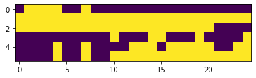

```python
plt.imshow(TF_2.values)
```

```python
pd.concat(se_2, axis=1)
```

|  | 0 | 1 | 2 | 3 | 4 | 5 | 6 | 7 | 8 | 9 | 10 | 11 | 12 | 13 | 14 | 15 | 16 | 17 | 18 | 19 | 20 | 21 | 22 | 23 | 24 |
| --- | --- | --- | --- | --- | --- | --- | --- | --- | --- | --- | --- | --- | --- | --- | --- | --- | --- | --- | --- | --- | --- | --- | --- | --- | --- |
| Intercept | 0.008781 | 0.004613 | 0.004399 | 0.003899 | 0.005109 | 0.003257 | 0.002596 | 0.002370 | 0.002262 | 0.002829 | 0.003760 | 0.002644 | 0.002457 | 0.002400 | 0.002726 | 0.003573 | 0.002971 | 0.002960 | 0.002844 | 0.003054 | 0.002784 | 0.002747 | 0.003033 | 0.003334 | 0.002797 |
| market | 0.219816 | 0.115486 | 0.110133 | 0.097617 | 0.127892 | 0.081536 | 0.064977 | 0.059324 | 0.056620 | 0.070821 | 0.094132 | 0.066200 | 0.061513 | 0.060086 | 0.068252 | 0.089454 | 0.074387 | 0.074094 | 0.071187 | 0.076447 | 0.069687 | 0.068769 | 0.075924 | 0.083455 | 0.070009 |
| factor0 | 0.318295 | 0.167224 | 0.159473 | 0.141350 | 0.185188 | 0.118064 | 0.094088 | 0.085902 | 0.081986 | 0.102549 | 0.136304 | 0.095858 | 0.089071 | 0.087005 | 0.098829 | 0.129530 | 0.107713 | 0.107289 | 0.103079 | 0.110696 | 0.100907 | 0.099578 | 0.109938 | 0.120843 | 0.101373 |
| factor1 | 0.304910 | 0.160192 | 0.152767 | 0.135405 | 0.177400 | 0.113099 | 0.090131 | 0.082289 | 0.078538 | 0.098236 | 0.130572 | 0.091826 | 0.085325 | 0.083346 | 0.094672 | 0.124082 | 0.103183 | 0.102777 | 0.098744 | 0.106041 | 0.096663 | 0.095390 | 0.105314 | 0.115761 | 0.097110 |
| factor2 | 0.538645 | 0.282990 | 0.269873 | 0.239204 | 0.313390 | 0.199798 | 0.159223 | 0.145370 | 0.138743 | 0.173541 | 0.230665 | 0.162218 | 0.150733 | 0.147236 | 0.167246 | 0.219200 | 0.182281 | 0.181563 | 0.174438 | 0.187328 | 0.170763 | 0.168514 | 0.186046 | 0.204500 | 0.171551 |
| factor3 | 0.648055 | 0.340471 | 0.324690 | 0.287791 | 0.377046 | 0.240381 | 0.191564 | 0.174898 | 0.166924 | 0.208791 | 0.277517 | 0.195168 | 0.181350 | 0.177143 | 0.201217 | 0.263724 | 0.219306 | 0.218442 | 0.209870 | 0.225379 | 0.205448 | 0.202743 | 0.223835 | 0.246038 | 0.206397 |

```python
r_2
```

```
[0.25783321219855904,
 0.6321271353830658,
 0.644897934399647,
 0.65622637974727,
 0.5546111666400055,
 0.7140931406705627,
 0.8430335011902266,
 0.8467868766753167,
 0.8356754565797844,
 0.7754442961140828,
 0.6835324806003273,
 0.8323503126411215,
 0.7856550835047349,
 0.8173085131351486,
 0.7644307319455415,
 0.6996532400877093,
 0.7080376820875735,
 0.6717162016109723,
 0.6759990383086816,
 0.6402774394868207,
 0.7412682032641875,
 0.6575712769477934,
 0.5884025811003627,
 0.5194439829363591,
 0.6444480441724416]
```

```python
shaped_r2= reshape(pd.Series(r_2), 'OP', 5,'Size',5)
shaped_int_coef2 = reshape(coef_2_table.loc['Intercept',:], 'OP', 5,'Size',5)
shaped_mkt_coef2 = reshape(coef_2_table.loc['market',:], 'OP', 5,'Size',5)
shaped_SMB_coef2 = reshape(coef_2_table.loc['factor0',:], 'OP', 5,'Size',5)
shaped_HMLO_coef2 = reshape(coef_2_table.loc['factor1',:], 'OP', 5,'Size',5)
shaped_RMW_coef2 = reshape(coef_2_table.loc['factor2',:], 'OP', 5,'Size',5)
shaped_CMA_coef2 = reshape(coef_2_table.loc['factor3',:], 'OP', 5,'Size',5)
```

```python
shaped_int_t2 = reshape(tvalues_2_table.loc['Intercept',:], 'OP', 5,'Size',5)
shaped_mkt_t2 = reshape(tvalues_2_table.loc['market',:], 'OP', 5,'Size',5)
shaped_SMB_t2 = reshape(tvalues_2_table.loc['factor0',:], 'OP', 5,'Size',5)
shaped_HMLO_t2 = reshape(tvalues_2_table.loc['factor1',:], 'OP', 5,'Size',5)
shaped_RMW_t2 = reshape(tvalues_2_table.loc['factor2',:], 'OP', 5,'Size',5)
shaped_CMA_t2 = reshape(tvalues_2_table.loc['factor3',:], 'OP', 5,'Size',5)
```

```python
shaped_CMA_t2
```

| OP Size | 1 | 2 | 3 | 4 | 5 |
| --- | --- | --- | --- | --- | --- |
| 1 | 1.838064 | 0.577902 | -0.668978 | -0.513252 | 2.483522 |
| 2 | 1.732478 | 1.942262 | 2.352579 | 1.377142 | 1.141426 |
| 3 | 3.449750 | 2.287965 | 3.000749 | 3.142373 | 2.086696 |
| 4 | 4.138829 | 4.507550 | 5.000020 | 2.736047 | 2.418696 |
| 5 | 3.227223 | 3.081689 | 2.148886 | 2.076998 | 2.795572 |

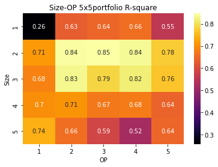

```python
os.chdir('C:\\Users\\jky93\\KYdrive\\바탕 화면\\창업\\아티클')
sns.heatmap(shaped_r2, cmap='inferno', annot=True)
plt.title('Size-OP 5x5portfolio R-square')
plt.savefig('r2.png', dpi=400)
```

### 3. (size/INV)로 25포트폴리오에 대해 OLS분석

```python
# INV pfo
cma_pfo_mask = make_portfolio(get_mask(Market_cap[0], Market_cap[1], breakpoint = [0.2, 0.4, 0.6, 0.8], market_bp='KOSPI'), CMA_base_shifted, breakpoint = [0.2, 0.4, 0.6, 0.8])

pfo25_cma_pfo = serialize_pfo([get_mask(Market_cap[0], Market_cap[1], breakpoint = [0.2, 0.4, 0.6, 0.8], market_bp='KOSPI'), cma_pfo_mask])

pfo_return_cma_pfo = get_factor_on_date_by_mask(pfo25_cma_pfo, term = 'm', winsorize_limits= 0.01, weight = 'VW')
```

#### 3. (size/INV)로 25포트폴리오에 대해 OLS분석

```
(1) Rm, SMB, HML, RMW, CMA로 regression
```

```python
coef = []
tvalues = []
pvalues = []
se = []
r = []
for i in range(25):
    model = get_ols_model(pfo25_cma_pfo, factors['Rm'], pfo_return_cma_pfo.iloc[:,i], cd_91, factors['SMB'], factors['HML'], factors['RMW'], factors['CMA'])
    coef.append(model.params)
    tvalues.append(model.tvalues)
    pvalues.append(model.pvalues)
    se.append(model.bse)
    r.append(model.rsquared_adj)
```

```python
pd.concat(coef, axis=1)
```

|  | 0 | 1 | 2 | 3 | 4 | 5 | 6 | 7 | 8 | 9 | 10 | 11 | 12 | 13 | 14 | 15 | 16 | 17 | 18 | 19 | 20 | 21 | 22 | 23 | 24 |
| --- | --- | --- | --- | --- | --- | --- | --- | --- | --- | --- | --- | --- | --- | --- | --- | --- | --- | --- | --- | --- | --- | --- | --- | --- | --- |
| Intercept | 0.012569 | 0.012037 | 0.011067 | 0.012678 | 0.012540 | -0.002715 | 0.000478 | 0.001780 | 0.004150 | 0.002020 | -0.000615 | 0.001632 | -0.001264 | 0.000645 | -0.003377 | 0.000669 | 0.002793 | -0.002124 | 0.001994 | -0.002387 | 0.003545 | -0.001456 | -0.001603 | 0.006038 | -0.000111 |
| market | 0.435617 | 0.619372 | 0.648543 | 0.505274 | 0.716459 | 0.458038 | 0.599387 | 0.628608 | 0.590771 | 0.603739 | 0.500588 | 0.588829 | 0.631070 | 0.620312 | 0.556697 | 0.586317 | 0.457026 | 0.560949 | 0.395550 | 0.605185 | 0.512452 | 0.898697 | 0.729453 | 1.690546 | 0.751021 |
| factor0 | 0.969343 | 1.401882 | 1.200640 | 1.346006 | 1.330071 | 1.113523 | 1.236621 | 1.174919 | 1.104184 | 1.077168 | 0.771008 | 1.031705 | 0.879671 | 0.822222 | 0.913253 | 0.474541 | 0.542796 | 0.546497 | 0.607532 | 0.701058 | -0.425170 | -0.126696 | -0.070182 | -0.286741 | 0.102153 |
| factor1 | -0.400702 | 0.149607 | -0.031381 | 0.079710 | 0.192513 | -0.229330 | 0.008054 | 0.112851 | 0.046099 | 0.052379 | -0.606594 | 0.027262 | 0.073454 | 0.025424 | -0.148631 | -0.457566 | -0.119682 | 0.120370 | -0.221027 | -0.273627 | 0.014530 | 0.200443 | 0.143635 | 0.063017 | -0.272328 |
| factor2 | 0.373218 | 0.002744 | 0.056185 | 0.250618 | 0.040596 | 0.268903 | 0.232351 | 0.083129 | 0.314432 | 0.109804 | 0.140870 | 0.057537 | 0.409092 | 0.412770 | 0.242409 | 0.374828 | 0.633756 | 0.657351 | 0.506890 | 0.547778 | 0.314135 | 0.076148 | 0.154920 | -0.114034 | 0.080216 |
| factor3 | 1.136638 | 0.063290 | 0.151900 | 0.307862 | -0.034890 | 0.613373 | 0.528099 | 0.146628 | 0.278577 | 0.308437 | 1.310859 | 0.392471 | 0.555186 | 0.491163 | 0.443633 | 1.397503 | 1.160543 | 0.858400 | 0.845254 | 0.598949 | 1.555862 | 0.418258 | 0.309244 | -0.848592 | -0.080968 |

```python
pd.concat(tvalues, axis=1)
```

|  | 0 | 1 | 2 | 3 | 4 | 5 | 6 | 7 | 8 | 9 | 10 | 11 | 12 | 13 | 14 | 15 | 16 | 17 | 18 | 19 | 20 | 21 | 22 | 23 | 24 |
| --- | --- | --- | --- | --- | --- | --- | --- | --- | --- | --- | --- | --- | --- | --- | --- | --- | --- | --- | --- | --- | --- | --- | --- | --- | --- |
| Intercept | 1.288015 | 2.759236 | 2.647392 | 3.667282 | 2.641216 | -0.863926 | 0.181343 | 0.726719 | 1.821045 | 0.776188 | -0.160827 | 0.586306 | -0.514314 | 0.274534 | -1.136427 | 0.200282 | 0.891754 | -0.763034 | 0.628860 | -0.772741 | 1.534902 | -0.465004 | -0.618137 | 1.349180 | -0.039021 |
| market | 1.782312 | 5.668442 | 6.194351 | 5.835517 | 6.025038 | 5.819040 | 9.081733 | 10.245359 | 10.351087 | 9.261753 | 5.229651 | 8.446564 | 10.248390 | 10.548236 | 7.480548 | 7.011300 | 5.826437 | 8.046725 | 4.979626 | 7.820932 | 8.858917 | 11.457586 | 11.229854 | 15.081788 | 10.538178 |
| factor0 | 2.734530 | 8.846051 | 7.906708 | 10.718294 | 7.712042 | 9.753836 | 12.918856 | 13.203271 | 13.339329 | 11.393403 | 5.553638 | 10.204041 | 9.849732 | 9.640183 | 8.461197 | 3.912608 | 4.771168 | 5.405170 | 5.273392 | 6.246695 | -5.067768 | -1.113698 | -0.744958 | -1.763769 | 0.988305 |
| factor1 | -1.182856 | 0.987862 | -0.216251 | 0.664195 | 1.168048 | -2.102047 | 0.088050 | 1.327041 | 0.582764 | 0.579740 | -4.572171 | 0.282153 | 0.860653 | 0.311922 | -1.440973 | -3.947772 | -1.100834 | 1.245788 | -2.007572 | -2.551295 | 0.181234 | 1.843750 | 1.595403 | 0.405617 | -2.757002 |
| factor2 | 0.621273 | 0.010217 | 0.218330 | 1.177621 | 0.138896 | 1.389906 | 1.432339 | 0.551240 | 2.241474 | 0.685337 | 0.598757 | 0.335800 | 2.702960 | 2.855738 | 1.325266 | 1.823640 | 3.287187 | 3.836482 | 2.596264 | 2.880153 | 2.209448 | 0.394985 | 0.970345 | -0.413906 | 0.457947 |
| factor3 | 1.562213 | 0.194574 | 0.487366 | 1.194394 | -0.098562 | 2.617665 | 2.687915 | 0.802794 | 1.639651 | 1.589460 | 4.600315 | 1.891200 | 3.028696 | 2.805656 | 2.002523 | 5.613816 | 4.970065 | 4.136420 | 3.574551 | 2.600156 | 9.035199 | 1.791281 | 1.599255 | -2.543103 | -0.381653 |

```python
pv = pd.concat(pvalues, axis=1)
pv
```

|  | 0 | 1 | 2 | 3 | 4 | 5 | 6 | 7 | 8 | 9 | 10 | 11 | 12 | 13 | 14 | 15 | 16 | 17 | 18 | 19 | 20 | 21 | 22 | 23 | 24 |
| --- | --- | --- | --- | --- | --- | --- | --- | --- | --- | --- | --- | --- | --- | --- | --- | --- | --- | --- | --- | --- | --- | --- | --- | --- | --- |
| Intercept | 0.200349 | 6.751720e-03 | 9.259578e-03 | 3.739863e-04 | 9.419958e-03 | 3.894424e-01 | 8.564201e-01 | 4.688876e-01 | 7.122258e-02 | 4.392453e-01 | 8.725143e-01 | 5.588287e-01 | 6.080279e-01 | 7.841709e-01 | 2.581612e-01 | 8.416170e-01 | 3.744030e-01 | 4.470190e-01 | 5.306989e-01 | 4.412750e-01 | 1.275786e-01 | 6.428154e-01 | 5.377178e-01 | 1.799528e-01 | 9.689420e-01 |
| market | 0.077360 | 1.102191e-07 | 9.545539e-09 | 5.124693e-08 | 2.121922e-08 | 5.529427e-08 | 3.807945e-15 | 7.416017e-18 | 4.197310e-18 | 1.456727e-15 | 7.791709e-07 | 1.103554e-13 | 7.295994e-18 | 1.451942e-18 | 1.661373e-11 | 1.776632e-10 | 5.343991e-08 | 8.958987e-13 | 2.284048e-06 | 2.891212e-12 | 1.246267e-14 | 1.092160e-20 | 3.709163e-20 | 6.339827e-29 | 1.532744e-18 |
| factor0 | 0.007245 | 1.334394e-14 | 1.854514e-12 | 5.811739e-19 | 5.070688e-12 | 1.042740e-16 | 4.565299e-24 | 1.022229e-24 | 5.008593e-25 | 1.541190e-20 | 1.853315e-07 | 9.263195e-18 | 6.229176e-17 | 1.919339e-16 | 1.021712e-13 | 1.556914e-04 | 5.469997e-06 | 3.599491e-07 | 6.435987e-07 | 7.441562e-09 | 1.568643e-06 | 2.677515e-01 | 4.578301e-01 | 8.044977e-02 | 3.250963e-01 |
| factor1 | 0.239327 | 3.253125e-01 | 8.291786e-01 | 5.079068e-01 | 2.452243e-01 | 3.775092e-02 | 9.299911e-01 | 1.871468e-01 | 5.612034e-01 | 5.632340e-01 | 1.233050e-05 | 7.783376e-01 | 3.912359e-01 | 7.556694e-01 | 1.523334e-01 | 1.368898e-04 | 2.732878e-01 | 2.153966e-01 | 4.705402e-02 | 1.205685e-02 | 8.565059e-01 | 6.781660e-02 | 1.133907e-01 | 6.857845e-01 | 6.795064e-03 |
| factor2 | 0.535660 | 9.918657e-01 | 8.275622e-01 | 2.414003e-01 | 8.897770e-01 | 1.672655e-01 | 1.547833e-01 | 5.825483e-01 | 2.693143e-02 | 4.945227e-01 | 5.505230e-01 | 7.376388e-01 | 7.923889e-03 | 5.103275e-03 | 1.877328e-01 | 7.082630e-02 | 1.345621e-03 | 2.051772e-04 | 1.066494e-02 | 4.749261e-03 | 2.914236e-02 | 6.935917e-01 | 3.339290e-01 | 6.797207e-01 | 6.478621e-01 |
| factor3 | 0.121010 | 8.460728e-01 | 6.269351e-01 | 2.348032e-01 | 9.216593e-01 | 1.005483e-02 | 8.267104e-03 | 4.237641e-01 | 1.038344e-01 | 1.147262e-01 | 1.100551e-05 | 6.113561e-02 | 3.038406e-03 | 5.906187e-03 | 4.760206e-02 | 1.412344e-07 | 2.378527e-06 | 6.775332e-05 | 5.156502e-04 | 1.055157e-02 | 4.879609e-15 | 7.590154e-02 | 1.125318e-01 | 1.232732e-02 | 7.034295e-01 |

```python
pv<0.1
```

|  | 0 | 1 | 2 | 3 | 4 | 5 | 6 | 7 | 8 | 9 | 10 | 11 | 12 | 13 | 14 | 15 | 16 | 17 | 18 | 19 | 20 | 21 | 22 | 23 | 24 |
| --- | --- | --- | --- | --- | --- | --- | --- | --- | --- | --- | --- | --- | --- | --- | --- | --- | --- | --- | --- | --- | --- | --- | --- | --- | --- |
| Intercept | False | True | True | True | True | False | False | False | True | False | False | False | False | False | False | False | False | False | False | False | False | False | False | False | False |
| market | True | True | True | True | True | True | True | True | True | True | True | True | True | True | True | True | True | True | True | True | True | True | True | True | True |
| factor0 | True | True | True | True | True | True | True | True | True | True | True | True | True | True | True | True | True | True | True | True | True | False | False | True | False |
| factor1 | False | False | False | False | False | True | False | False | False | False | True | False | False | False | False | True | False | False | True | True | False | True | False | False | True |
| factor2 | False | False | False | False | False | False | False | False | True | False | False | False | True | True | False | True | True | True | True | True | True | False | False | False | False |
| factor3 | False | False | False | False | False | True | True | False | False | False | True | True | True | True | True | True | True | True | True | True | True | True | False | True | False |

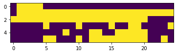

```python
TF =pv<0.05
plt.imshow(TF.values)
```

```python
r
```

```
[0.22159223431771835,
 0.66224717126601,
 0.6369668254185257,
 0.7317701003880448,
 0.617420237599102,
 0.7306014992314364,
 0.841599099258226,
 0.8375218184309722,
 0.8370507902944053,
 0.8123974817731476,
 0.698218865358058,
 0.7928121483195706,
 0.8146672562558507,
 0.8067212873905927,
 0.7156780325650386,
 0.7203775114919091,
 0.6710398992687355,
 0.7216448916529264,
 0.5915049938777415,
 0.6581116370244418,
 0.7871235048688733,
 0.6750701313662153,
 0.6517254572510081,
 0.6790779626328753,
 0.5509686812686918]
```

#### 3. (size/INV)로 25포트폴리오에 대해 OLS분석

```
(2) HML를 다른 4개 팩터에 projection시켜서 HMLO로 대체
```

```python
coef_3 = []
tvalues_3 = []
pvalues_3 = []
se_3 = []
r_3 = []
for i in range(25):
    model = get_ols_model(pfo25_cma_pfo, factors['Rm'], pfo_return_cma_pfo.iloc[:,i], cd_91, factors['SMB'], factors['HMLO'], factors['RMW'], factors['CMA'])
    coef_3.append(model.params)
    tvalues_3.append(model.tvalues)
    pvalues_3.append(model.pvalues)
    se_3.append(model.bse)
    r_3.append(model.rsquared_adj)
```

```python
coef_3_table = pd.concat(coef_3, axis=1)
coef_3_table
```

|  | 0 | 1 | 2 | 3 | 4 | 5 | 6 | 7 | 8 | 9 | 10 | 11 | 12 | 13 | 14 | 15 | 16 | 17 | 18 | 19 | 20 | 21 | 22 | 23 | 24 |
| --- | --- | --- | --- | --- | --- | --- | --- | --- | --- | --- | --- | --- | --- | --- | --- | --- | --- | --- | --- | --- | --- | --- | --- | --- | --- |
| Intercept | 0.012552 | 0.012044 | 0.011065 | 0.012681 | 0.012549 | -0.002725 | 0.000478 | 0.001785 | 0.004152 | 0.002023 | -0.000643 | 0.001633 | -0.001261 | 0.000646 | -0.003384 | 0.000647 | 0.002787 | -0.002118 | 0.001984 | -0.002400 | 0.003545 | -0.001447 | -0.001597 | 0.006042 | -0.000124 |
| market | 0.424129 | 0.623661 | 0.647643 | 0.507559 | 0.721978 | 0.451463 | 0.599618 | 0.631843 | 0.592093 | 0.605241 | 0.483197 | 0.589611 | 0.633176 | 0.621041 | 0.552435 | 0.573199 | 0.453595 | 0.564400 | 0.389214 | 0.597340 | 0.512868 | 0.904443 | 0.733571 | 1.692353 | 0.743214 |
| factor0 | 0.940342 | 1.412710 | 1.198368 | 1.351775 | 1.344004 | 1.096925 | 1.237204 | 1.183087 | 1.107520 | 1.080959 | 0.727105 | 1.033678 | 0.884987 | 0.824062 | 0.902495 | 0.441425 | 0.534134 | 0.555209 | 0.591535 | 0.681254 | -0.424119 | -0.112188 | -0.059787 | -0.282180 | 0.082443 |
| factor1 | -0.401042 | 0.149567 | -0.031395 | 0.079787 | 0.192431 | -0.229376 | 0.008097 | 0.112861 | 0.046137 | 0.052355 | -0.606629 | 0.027226 | 0.073398 | 0.025360 | -0.148606 | -0.457438 | -0.119616 | 0.120333 | -0.221019 | -0.273690 | 0.014588 | 0.200538 | 0.143767 | 0.062869 | -0.272245 |
| factor2 | 0.435199 | -0.020397 | 0.061039 | 0.238289 | 0.010818 | 0.304376 | 0.231105 | 0.065673 | 0.307301 | 0.101702 | 0.234698 | 0.053320 | 0.397730 | 0.408837 | 0.265399 | 0.445605 | 0.652269 | 0.638732 | 0.541078 | 0.590103 | 0.311887 | 0.045144 | 0.132703 | -0.123782 | 0.122340 |
| factor3 | 1.012862 | 0.109503 | 0.142207 | 0.332484 | 0.024577 | 0.542534 | 0.530587 | 0.181488 | 0.292817 | 0.324617 | 1.123484 | 0.400892 | 0.577876 | 0.499016 | 0.397721 | 1.256162 | 1.123573 | 0.895582 | 0.776980 | 0.514426 | 1.560350 | 0.480175 | 0.353613 | -0.829126 | -0.165090 |

```python
tvalues_3_table = pd.concat(tvalues_3, axis=1)
tvalues_3_table
```

|  | 0 | 1 | 2 | 3 | 4 | 5 | 6 | 7 | 8 | 9 | 10 | 11 | 12 | 13 | 14 | 15 | 16 | 17 | 18 | 19 | 20 | 21 | 22 | 23 | 24 |
| --- | --- | --- | --- | --- | --- | --- | --- | --- | --- | --- | --- | --- | --- | --- | --- | --- | --- | --- | --- | --- | --- | --- | --- | --- | --- |
| Intercept | 1.286627 | 2.761592 | 2.647757 | 3.669228 | 2.643862 | -0.867477 | 0.181458 | 0.729031 | 1.822391 | 0.777369 | -0.168193 | 0.586977 | -0.512953 | 0.275237 | -1.139084 | 0.193787 | 0.890112 | -0.761163 | 0.625780 | -0.776968 | 1.535483 | -0.462307 | -0.615980 | 1.350340 | -0.043609 |
| market | 1.736678 | 5.712130 | 6.190578 | 5.866498 | 6.076151 | 5.740022 | 9.092313 | 10.306126 | 10.382352 | 9.292011 | 5.051942 | 8.464357 | 10.290548 | 10.568836 | 7.429048 | 6.859496 | 5.787164 | 8.102501 | 4.903661 | 7.725663 | 8.873037 | 11.539995 | 11.302276 | 15.109617 | 10.436528 |
| factor0 | 2.659114 | 8.935758 | 7.910700 | 10.790118 | 7.811500 | 9.631588 | 12.955983 | 13.326992 | 13.411792 | 11.460936 | 5.250020 | 10.248092 | 9.933001 | 9.684933 | 8.381580 | 3.648152 | 4.706273 | 5.504496 | 5.146857 | 6.084884 | -5.067376 | -0.988556 | -0.636148 | -1.739876 | 0.799514 |
| factor1 | -1.183861 | 0.987585 | -0.216342 | 0.664831 | 1.167528 | -2.102464 | 0.088511 | 1.327141 | 0.583238 | 0.579470 | -4.572416 | 0.281769 | 0.859978 | 0.311130 | -1.440709 | -3.946464 | -1.100212 | 1.245386 | -2.007479 | -2.551888 | 0.181956 | 1.844636 | 1.596873 | 0.404659 | -2.756070 |
| factor2 | 0.727222 | -0.076239 | 0.238099 | 1.123965 | 0.037154 | 1.579278 | 1.430098 | 0.437150 | 2.199011 | 0.637191 | 1.001386 | 0.312377 | 2.637909 | 2.839324 | 1.456491 | 2.176179 | 3.396105 | 3.742033 | 2.781953 | 3.114578 | 2.202017 | 0.235060 | 0.834374 | -0.451000 | 0.701081 |
| factor3 | 1.406760 | 0.340192 | 0.461067 | 1.303500 | 0.070159 | 2.339733 | 2.729003 | 1.004110 | 1.741609 | 1.690443 | 3.984271 | 1.952110 | 3.185640 | 2.880513 | 1.814170 | 5.098950 | 4.862357 | 4.360994 | 3.320398 | 2.256759 | 9.156645 | 2.078125 | 1.847993 | -2.510910 | -0.786342 |

```python
pv_3 = pd.concat(pvalues_3, axis=1)
pv_3
```

|  | 0 | 1 | 2 | 3 | 4 | 5 | 6 | 7 | 8 | 9 | 10 | 11 | 12 | 13 | 14 | 15 | 16 | 17 | 18 | 19 | 20 | 21 | 22 | 23 | 24 |
| --- | --- | --- | --- | --- | --- | --- | --- | --- | --- | --- | --- | --- | --- | --- | --- | --- | --- | --- | --- | --- | --- | --- | --- | --- | --- |
| Intercept | 0.200831 | 6.706293e-03 | 9.250161e-03 | 3.714514e-04 | 9.350943e-03 | 3.875029e-01 | 8.563305e-01 | 4.674779e-01 | 7.101691e-02 | 4.385515e-01 | 8.667292e-01 | 5.583798e-01 | 6.089765e-01 | 7.836323e-01 | 2.570561e-01 | 8.466872e-01 | 3.752801e-01 | 4.481313e-01 | 0.532710 | 4.387871e-01 | 1.274361e-01 | 6.447422e-01 | 5.391354e-01 | 1.795817e-01 | 9.652927e-01 |
| market | 0.085145 | 9.031412e-08 | 9.718042e-09 | 4.440899e-08 | 1.669033e-08 | 7.949776e-08 | 3.599096e-15 | 5.346844e-18 | 3.547019e-18 | 1.239185e-15 | 1.678582e-06 | 1.004847e-13 | 5.814599e-18 | 1.299506e-18 | 2.160123e-11 | 3.779919e-10 | 6.403454e-08 | 6.698934e-13 | 0.000003 | 4.727159e-12 | 1.156217e-14 | 7.020184e-21 | 2.513777e-20 | 5.507828e-29 | 2.649573e-18 |
| factor0 | 0.008962 | 8.284203e-15 | 1.816525e-12 | 3.948169e-19 | 3.035648e-12 | 2.009922e-16 | 3.753731e-24 | 5.342924e-25 | 3.427647e-25 | 1.072708e-20 | 7.128863e-07 | 7.307687e-18 | 3.981420e-17 | 1.509549e-16 | 1.553337e-13 | 3.997906e-04 | 7.146560e-06 | 2.311140e-07 | 0.000001 | 1.601801e-08 | 1.571279e-06 | 3.249741e-01 | 5.259552e-01 | 8.457955e-02 | 4.256551e-01 |
| factor1 | 0.238931 | 3.254473e-01 | 8.291082e-01 | 5.075013e-01 | 2.454333e-01 | 3.771365e-02 | 9.296260e-01 | 1.871138e-01 | 5.608849e-01 | 5.634157e-01 | 1.231834e-05 | 7.786312e-01 | 3.916060e-01 | 7.562701e-01 | 1.524078e-01 | 1.375485e-04 | 2.735578e-01 | 2.155437e-01 | 0.047064 | 1.203748e-02 | 8.559408e-01 | 6.768655e-02 | 1.130624e-01 | 6.864865e-01 | 6.813221e-03 |
| factor2 | 0.468581 | 9.393622e-01 | 8.122321e-01 | 2.633890e-01 | 9.704276e-01 | 1.170432e-01 | 1.554239e-01 | 6.628294e-01 | 2.989627e-02 | 5.252781e-01 | 3.187612e-01 | 7.553247e-01 | 9.506869e-03 | 5.354695e-03 | 1.480056e-01 | 3.160506e-02 | 9.416137e-04 | 2.875051e-04 | 0.006325 | 2.330118e-03 | 2.967740e-02 | 8.145840e-01 | 4.058152e-01 | 6.528463e-01 | 4.846811e-01 |
| factor3 | 0.162219 | 7.343380e-01 | 6.456293e-01 | 1.950304e-01 | 9.441903e-01 | 2.103776e-02 | 7.360211e-03 | 3.174520e-01 | 8.427433e-02 | 9.367582e-02 | 1.196755e-04 | 5.337725e-02 | 1.863358e-03 | 4.744223e-03 | 7.228162e-02 | 1.372163e-06 | 3.743193e-06 | 2.853724e-05 | 0.001208 | 2.592894e-02 | 2.553655e-15 | 3.994263e-02 | 6.719548e-02 | 1.344365e-02 | 4.332989e-01 |

```python
pv_3<0.1 #True이면 통계적 유의성 충분. (설명력 ㅇ)
```

|  | 0 | 1 | 2 | 3 | 4 | 5 | 6 | 7 | 8 | 9 | 10 | 11 | 12 | 13 | 14 | 15 | 16 | 17 | 18 | 19 | 20 | 21 | 22 | 23 | 24 |
| --- | --- | --- | --- | --- | --- | --- | --- | --- | --- | --- | --- | --- | --- | --- | --- | --- | --- | --- | --- | --- | --- | --- | --- | --- | --- |
| Intercept | False | True | True | True | True | False | False | False | True | False | False | False | False | False | False | False | False | False | False | False | False | False | False | False | False |
| market | True | True | True | True | True | True | True | True | True | True | True | True | True | True | True | True | True | True | True | True | True | True | True | True | True |
| factor0 | True | True | True | True | True | True | True | True | True | True | True | True | True | True | True | True | True | True | True | True | True | False | False | True | False |
| factor1 | False | False | False | False | False | True | False | False | False | False | True | False | False | False | False | True | False | False | True | True | False | True | False | False | True |
| factor2 | False | False | False | False | False | False | False | False | True | False | False | False | True | True | False | True | True | True | True | True | True | False | False | False | False |
| factor3 | False | False | False | False | False | True | True | False | True | True | True | True | True | True | True | True | True | True | True | True | True | True | True | True | False |

```python
TF_3 =pv_3<0.05 #True이면 통계적 유의성 충분. (설명력 ㅇ)
TF_3
```

|  | 0 | 1 | 2 | 3 | 4 | 5 | 6 | 7 | 8 | 9 | 10 | 11 | 12 | 13 | 14 | 15 | 16 | 17 | 18 | 19 | 20 | 21 | 22 | 23 | 24 |
| --- | --- | --- | --- | --- | --- | --- | --- | --- | --- | --- | --- | --- | --- | --- | --- | --- | --- | --- | --- | --- | --- | --- | --- | --- | --- |
| Intercept | False | True | True | True | True | False | False | False | False | False | False | False | False | False | False | False | False | False | False | False | False | False | False | False | False |
| market | False | True | True | True | True | True | True | True | True | True | True | True | True | True | True | True | True | True | True | True | True | True | True | True | True |
| factor0 | True | True | True | True | True | True | True | True | True | True | True | True | True | True | True | True | True | True | True | True | True | False | False | False | False |
| factor1 | False | False | False | False | False | True | False | False | False | False | True | False | False | False | False | True | False | False | True | True | False | False | False | False | True |
| factor2 | False | False | False | False | False | False | False | False | True | False | False | False | True | True | False | True | True | True | True | True | True | False | False | False | False |
| factor3 | False | False | False | False | False | True | True | False | False | False | True | False | True | True | False | True | True | True | True | True | True | True | False | True | False |

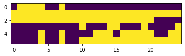

```python
plt.imshow(TF_2.values)
```

```python
pd.concat(se_3, axis=1)
```

|  | 0 | 1 | 2 | 3 | 4 | 5 | 6 | 7 | 8 | 9 | 10 | 11 | 12 | 13 | 14 | 15 | 16 | 17 | 18 | 19 | 20 | 21 | 22 | 23 | 24 |
| --- | --- | --- | --- | --- | --- | --- | --- | --- | --- | --- | --- | --- | --- | --- | --- | --- | --- | --- | --- | --- | --- | --- | --- | --- | --- |
| Intercept | 0.009756 | 0.004361 | 0.004179 | 0.003456 | 0.004746 | 0.003142 | 0.002634 | 0.002449 | 0.002278 | 0.002602 | 0.003821 | 0.002783 | 0.002458 | 0.002347 | 0.002970 | 0.003338 | 0.003131 | 0.002783 | 0.003171 | 0.003089 | 0.002309 | 0.003131 | 0.002593 | 0.004474 | 0.002845 |
| market | 0.244218 | 0.109182 | 0.104618 | 0.086518 | 0.118822 | 0.078652 | 0.065948 | 0.061308 | 0.057029 | 0.065136 | 0.095646 | 0.069658 | 0.061530 | 0.058761 | 0.074362 | 0.083563 | 0.078380 | 0.069658 | 0.079372 | 0.077319 | 0.057801 | 0.078375 | 0.064905 | 0.112005 | 0.071213 |
| factor0 | 0.353630 | 0.158096 | 0.151487 | 0.125279 | 0.172055 | 0.113888 | 0.095493 | 0.088774 | 0.082578 | 0.094317 | 0.138496 | 0.100865 | 0.089096 | 0.085087 | 0.107676 | 0.120999 | 0.113494 | 0.100865 | 0.114931 | 0.111958 | 0.083696 | 0.113487 | 0.093982 | 0.162184 | 0.103117 |
| factor1 | 0.338758 | 0.151448 | 0.145116 | 0.120010 | 0.164819 | 0.109099 | 0.091477 | 0.085040 | 0.079105 | 0.090350 | 0.132671 | 0.096624 | 0.085349 | 0.081509 | 0.103148 | 0.115911 | 0.108721 | 0.096623 | 0.110098 | 0.107250 | 0.080176 | 0.108714 | 0.090030 | 0.155363 | 0.098780 |
| factor2 | 0.598441 | 0.267543 | 0.256358 | 0.212007 | 0.291164 | 0.192731 | 0.161601 | 0.150230 | 0.139745 | 0.159611 | 0.234374 | 0.170692 | 0.150775 | 0.143991 | 0.182218 | 0.204765 | 0.192064 | 0.170691 | 0.194496 | 0.189465 | 0.141637 | 0.192052 | 0.159045 | 0.274461 | 0.174502 |
| factor3 | 0.719996 | 0.321887 | 0.308430 | 0.255070 | 0.350306 | 0.231878 | 0.194425 | 0.180745 | 0.168130 | 0.192031 | 0.281980 | 0.205364 | 0.181400 | 0.173239 | 0.219230 | 0.246357 | 0.231076 | 0.205362 | 0.234002 | 0.227949 | 0.170406 | 0.231062 | 0.191350 | 0.330209 | 0.209947 |

```python
r_3
```

```
[0.22160827654585669,
 0.6622455673667555,
 0.6369669501959538,
 0.731772081877837,
 0.6174162082039267,
 0.7306054883111477,
 0.8415992121759848,
 0.8375221904049485,
 0.8370515792304176,
 0.8123969675850008,
 0.698223871038518,
 0.7928117551381342,
 0.8146653816628224,
 0.8067204512188487,
 0.7156761704292233,
 0.7203552315800883,
 0.671035986279489,
 0.7216424788583937,
 0.591503698283174,
 0.6581202241698481,
 0.7871239942064954,
 0.6750791715224804,
 0.6517394794944419,
 0.679075780967648,
 0.5509497082177021]
```

```python
shaped_r3= reshape(pd.Series(r_3), 'Inv', 5,'Size',5)
shaped_int_coef3 = reshape(coef_3_table.loc['Intercept',:], 'INV', 5,'Size',5)
shaped_mkt_coef3 = reshape(coef_3_table.loc['market',:], 'INV', 5,'Size',5)
shaped_SMB_coef3 = reshape(coef_3_table.loc['factor0',:], 'INV', 5,'Size',5)
shaped_HMLO_coef3 = reshape(coef_3_table.loc['factor1',:], 'INV', 5,'Size',5)
shaped_RMW_coef3 = reshape(coef_3_table.loc['factor2',:], 'INV', 5,'Size',5)
shaped_CMA_coef3 = reshape(coef_3_table.loc['factor3',:], 'INV', 5,'Size',5)
```

```python
shaped_int_t3 = reshape(tvalues_3_table.loc['Intercept',:], 'INV', 5,'Size',5)
shaped_mkt_t3 = reshape(tvalues_3_table.loc['market',:], 'INV', 5,'Size',5)
shaped_SMB_t3 = reshape(tvalues_3_table.loc['factor0',:], 'INV', 5,'Size',5)
shaped_HMLO_t3 = reshape(tvalues_3_table.loc['factor1',:], 'INV', 5,'Size',5)
shaped_RMW_t3 = reshape(tvalues_3_table.loc['factor2',:], 'INV', 5,'Size',5)
shaped_CMA_t3 = reshape(tvalues_3_table.loc['factor3',:], 'INV', 5,'Size',5)
```

```python
shaped_CMA_t3
```

| INV Size | 1 | 2 | 3 | 4 | 5 |
| --- | --- | --- | --- | --- | --- |
| 1 | 1.406760 | 0.340192 | 0.461067 | 1.303500 | 0.070159 |
| 2 | 2.339733 | 2.729003 | 1.004110 | 1.741609 | 1.690443 |
| 3 | 3.984271 | 1.952110 | 3.185640 | 2.880513 | 1.814170 |
| 4 | 5.098950 | 4.862357 | 4.360994 | 3.320398 | 2.256759 |
| 5 | 9.156645 | 2.078125 | 1.847993 | -2.510910 | -0.786342 |

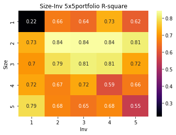

```python
os.chdir('C:\\Users\\jky93\\KYdrive\\바탕 화면\\창업\\아티클')
sns.heatmap(shaped_r3, cmap='inferno', annot=True)
plt.title('Size-Inv 5x5portfolio R-square')
plt.savefig('r3.png', dpi=400)
```